# Complex Analysis Qualifying Exam Solutions

# 1 Preface

I’d like to thank the following individuals for their contributions to this document:

- Edward Azoff, for supplying a problem sheet broken out by topic.
- Mentzelos Melistas, for explaining and documenting many solutions to these questions.
- Jingzhi Tie, for supplying many additional problems and solutions.

# 2 Topology and Functions of One Variable (8155a)

## 2.1 1 $\work$

Let $x_0 = a, x_1 = b$, and set
$$\begin{align*}
x_n \mathrel{\vcenter{:}}={x_{n-1} + x_{n-2} \over 2} \quad n\geq 2
.\end{align*}$$

Show that $\left\{{x_n}\right\}$ is a Cauchy sequence and find its limit in terms of $a$ and $b$.

## 2.2 2 $\work$

Suppose $f:{\mathbb{R}}\to{\mathbb{R}}$ is continuous and $\lim_{x\to \pm \infty} f(x) = 0$. Prove that $f$ is uniformly continuous.

## 2.3 3 $\work$

Give an example of a function $f:{\mathbb{R}}\to {\mathbb{R}}$ that is everywhere differentiable but $f'$ is not continuous at 0.

## 2.4 4 $\work$

Suppose $\left\{{g_n}\right\}$ is a uniformly convergent sequence of functions from ${\mathbb{R}}$ to ${\mathbb{R}}$ and $f:{\mathbb{R}}\to {\mathbb{R}}$ is uniformly continuous. Prove that the sequence $\left\{{f\circ g_n}\right\}$ is uniformly convergent.

## 2.5 5 $\work$

Let $f$ be differentiable on $[a, b]$. Say that $f$ is *uniformly differentiable* iff

$$\begin{align*}
\forall \varepsilon > 0,\, \exists \delta > 0 \text{ such that } \quad {\left\lvert {x-y} \right\rvert} < \delta \implies {\left\lvert { {f(x) - f(y) \over x-y} - f'(y)} \right\rvert} < \varepsilon
.\end{align*}$$

Prove that $f$ is uniformly differentiable on $[a, b] \iff f'$ is continuous on $[a, b]$.

## 2.6 6 $\work$

Suppose $A, B \subseteq {\mathbb{R}}^n$ are disjoint and compact. Prove that there exist $a\in A, b\in B$ such that
$$\begin{align*}
{\left\lVert {a - b} \right\rVert} = \inf\left\{{{\left\lVert {x-y} \right\rVert} {~\mathrel{\Big|}~}x\in A,\, y\in B}\right\}
.\end{align*}$$

## 2.7 7 $\work$

Suppose $A, B\subseteq {\mathbb{R}}^n$ are connected and not disjoint. Prove that $A\cup B$ is also connected.

## 2.8 8 $\work$

Suppose $\left\{{f_n}\right\}_{n\in {\mathbb{N}}}$ is a sequence of continuous functions $f_n: [0, 1]\to {\mathbb{R}}$ such that
$$\begin{align*}
f_n(x) \geq f_{n+1}(x) \geq 0 \quad \forall n\in {\mathbb{N}},\, \forall x\in [0, 1]
.\end{align*}
Prove that if \(\left\{{f_n}\right\}\) converges pointwise to \(0\) on \([0, 1]\) then it converges to \(0\) uniformly on \([0, 1]\).$$

## 2.9 9 $\work$

Show that if $E\subset [0, 1]$ is uncountable, then there is some $t\in {\mathbb{R}}$ such that $E\cap(-\infty ,t)$ and $E\cap(t, \infty)$ are also uncountable.

# 3 Several Variables (8155h)

## 3.1 1 $\work$

Is the following function continuous, differentiable, continuously differentiable?
$$\begin{align*}
f: {\mathbb{R}}^2 &\to {\mathbb{R}}\\
f(x, y) &=
\begin{cases}
{xy \over \sqrt{x^2 + y^2}} & (x, y) \neq (0, 0) \\
0 & \text{else}.
\end{cases}
\end{align*}$$

## 3.2 2 $\work$

### 3.2.1 a $\work$

Complete this definition: “$f: {\mathbb{R}}^n\to {\mathbb{R}}^m$ is real-differentiable a point $p\in {\mathbb{R}}^n$ iff there exists a linear transformation…”

### 3.2.2 b $\work$

Give an example of a function $f:{\mathbb{R}}^2\to {\mathbb{R}}$ whose first-order partial derivatives exist everywhere but $f$ is not differentiable at $(0, 0)$.

### 3.2.3 c $\work$

Give an example of a function $f: {\mathbb{R}}^2 \to {\mathbb{R}}$ which is real-differentiable everywhere but nowhere complex-differentiable.

## 3.3 3 $\work$

Let $f:{\mathbb{R}}^2\to {\mathbb{R}}$.

### 3.3.1 a $\work$

Define in terms of linear transformations what it means for $f$ to be differentiable at a point $(a, b) \in {\mathbb{R}}^2$.

### 3.3.2 b $\work$

State a version of the inverse function theorem in this setting.

### 3.3.3 c $\work$

Identify ${\mathbb{R}}^2$ with ${\mathbb{C}}$ and give a necessary and sufficient condition for a real-differentiable function at $(a, b)$ to be complex differentiable at the point $a+ib$.

## 3.4 4 $\work$

Let $f = u+iv$ be complex-differentiable with continuous partial derivatives at a point $z = re^{i\theta}$ with $r\neq 0$. Show that
$$\begin{align*}
{\frac{\partial u}{\partial r}\,} = {1\over r}{\frac{\partial v}{\partial \theta}\,} \qquad {\frac{\partial v}{\partial r}\,} = -{1\over r}{\frac{\partial u}{\partial \theta}\,}
.\end{align*}$$

## 3.5 5 $\work$

Let $P = (1, 3) \in {\mathbb{R}}^2$ and define
$$\begin{align*}
f(s, t) \mathrel{\vcenter{:}}= ps^3 -6st + t^2
.\end{align*}$$

### 3.5.1 a $\work$

State the conclusion of the implicit function theorem concerning $f(s, t) = 0$ when $f$ is considered a function ${\mathbb{R}}^2\to{\mathbb{R}}$.

### 3.5.2 b $\work$

State the above conclusion when $f$ is considered a function ${\mathbb{C}}^2\to {\mathbb{C}}$.

### 3.5.3 c $\work$

Use the implicit function theorem for a function ${\mathbb{R}}\times{\mathbb{R}}^2 \to {\mathbb{R}}^2$ to prove (b).

> There are various approaches: using the definition of the complex derivative, the Cauchy-Riemann equations, considering total derivatives, etc.

## 3.6 6 $\work$

Let $F:{\mathbb{R}}^2\to {\mathbb{R}}$ be continuously differentiable with $F(0, 0) = 0$ and ${\left\lVert {\nabla F(0, 0)} \right\rVert} < 1$.

Prove that there is some real number $r> 0$ such that ${\left\lvert {F(x, y)} \right\rvert} < r$ whenever ${\left\lVert {(x, y)} \right\rVert} < r$.

## 3.7 7 $\work$

State the most general version of the implicit function theorem for real functions and outline how it can be proved using the inverse function theorem.

# 4 Several Variables: Extra Questions

## 4.1 ?

Let $f=u+iv$ be differentiable (i.e. $f'(z)$ exists) with continuous partial derivatives at a point $z=re^{i\theta}$, $r\not= 0$.

Show that
$$\begin{align*}
\frac{\partial u}{\partial r}=\frac{1}{r}\frac{\partial v}{\partial \theta},\quad
\frac{\partial v}{\partial r}=-\frac{1}{r}\frac{\partial u}{\partial \theta}
.\end{align*}$$

## 4.2 ?

Show that $f(z) = z^2$ is uniformly continuous in any open disk $|z| < R$, where $R>0$ is fixed, but it is not uniformly continuous on $\mathbb C$.

### 4.2.1 1

Show that the function $u=u(x,y)$ given by
$$\begin{align*}
u(x,y)=\frac{e^{ny}-e^{-ny}}{2n^2}\sin nx\quad \text{for}\ n\in {\mathbf N}
\end{align*}
is the solution on \(D=\{(x,y)\ | x^2+y^2<1\}\) of the Cauchy problem for the Laplace equation
\begin{align*}\frac{\partial ^2u}{\partial x^2}+\frac{\partial ^2u}{\partial y^2}=0,\quad
u(x,0)=0,\quad \frac{\partial u}{\partial y}(x,0)=\frac{\sin nx}{n}.\end{align*}$$

### 4.2.2 2

Show that there exist points $(x,y)\in D$ such that $\displaystyle{\limsup_{n\to\infty} |u(x,y)|=\infty}$.

# 5 Conformal Maps (8155c)

> Notation: ${\mathbb{D}}$ is the open unit disc, ${\mathbb{H}}$ is the open upper half-plane.

## 5.1 1 $\work$

Find a conformal map from ${\mathbb{D}}$ to ${\mathbb{H}}$.

## 5.2 2 $\work$

Find a conformal map from the strip $\left\{{z\in {\mathbb{C}}{~\mathrel{\Big|}~}0 < \Im(z) < 1}\right\}$ to ${\mathbb{H}}$.

## 5.3 3 $\work$

Find a fractional linear transformation $T$ which maps ${\mathbb{H}}$ to ${\mathbb{D}}$, and explicitly describe the image of the first quadrant under $T$.

## 5.4 4 $\work$

Find a conformal map from $\left\{{z\in {\mathbb{C}}{~\mathrel{\Big|}~}{\left\lvert {z-i} \right\rvert} > 1,\, \Re(z) > 0}\right\}$ to ${\mathbb{H}}$.

## 5.5 5 $\work$

Find a conformal map from $\left\{{z\in {\mathbb{C}}{~\mathrel{\Big|}~}{\left\lvert {z} \right\rvert} < 1,\, {\left\lvert {z - {1\over 2}} \right\rvert} > {1\over 2} }\right\}$ to ${\mathbb{D}}$.

## 5.6 6 $\work$

Find a conformal map from $\left\{{{\left\lvert {z-1} \right\rvert} < 2}\right\} \cap\left\{{{\left\lvert {z+1} \right\rvert} < 2}\right\}$ to ${\mathbb{H}}$.

## 5.7 7 $\work$

Let $\Omega$ be the region inside the unit circle ${\left\lvert {z} \right\rvert} = 1$ and outside the circle ${\left\lvert {z-{1\over 4}} \right\rvert} = {1\over 4}$.

Find an injective conformal map from $\Omega$ onto some annulus $\left\{{r < {\left\lvert {z} \right\rvert} < 1}\right\}$ for gonstant $r$.

## 5.8 8 $\work$

Let $D$ be the region obtained by deleting the real interval $[0, 1)$ from ${\mathbb{D}}$; find a conformal map from $D$ to ${\mathbb{D}}$.

## 5.9 9 $\work$

Find a conformal map from ${\mathbb{C}}\setminus\left\{{x\in {\mathbb{R}}{~\mathrel{\Big|}~}x\leq 0}\right\}$ to ${\mathbb{D}}$.

## 5.10 10 $\work$

Find a conformal map from ${\mathbb{C}}\setminus\left\{{x\in {\mathbb{R}}{~\mathrel{\Big|}~}x\geq 1}\right\}$ to ${\mathbb{D}}$.

## 5.11 11 $\work$

Find a bijective conformal map from $G$ to ${\mathbb{H}}$, where
$$\begin{align*}
G \mathrel{\vcenter{:}}=\left\{{z\in {\mathbb{C}}{~\mathrel{\Big|}~}{\left\lvert {z-1} \right\rvert} < \sqrt 2,\, {\left\lvert {z+1} \right\rvert} < \sqrt 2}\right\} \setminus [0, i)
.\end{align*}$$

## 5.12 12 $\work$

Prove that TFAE for a Möbius transformation $T$ given by $T(z) = {az + b \over cz + d}$:

1. $T$ maps ${\mathbb{R}}\cup\left\{{\infty}\right\}$ to itself.
2. It is possible to choose $a,b,c,d$ to be real numbers.
3. $\mkern 1.5mu\overline{\mkern-1.5muT(z)\mkern-1.5mu}\mkern 1.5mu = T(\mkern 1.5mu\overline{\mkern-1.5muz\mkern-1.5mu}\mkern 1.5mu)$ for every $z\in {\mathbb{CP}}^1$.
4. There exist $\alpha\in {\mathbb{R}}, \beta \in {\mathbb{C}}\setminus {\mathbb{R}}$ such that $T(\alpha) = \alpha$ and $T(\mkern 1.5mu\overline{\mkern-1.5mu\beta\mkern-1.5mu}\mkern 1.5mu) = \mkern 1.5mu\overline{\mkern-1.5muT(\beta)\mkern-1.5mu}\mkern 1.5mu$.

# 6 Extra Questions

## 6.1 12.

Find a conformal map from $D = \{z :\ |z| < 1,\ |z - 1/2| > 1/2\}$ to the unit disk $\Delta=\{z: \ |z|<1\}$.

# 7 Integrals and Cauchy’s Theorem (8155d)

> Some interesting problems: 3, 4, 9, 10.

## 7.1 1 $\work$

Suppose $f, g: [0, 1] \to {\mathbb{R}}$ where $f$ is Riemann integrable and for $x, y\in [0, 1]$,
$$\begin{align*}
{\left\lvert {g(x) - g(y)} \right\rvert} \leq {\left\lvert {f(x) - f(y)} \right\rvert}
.\end{align*}$$

Prove that $g$ is Riemann integrable.

## 7.2 2 $\work$

State and prove Green’s Theorem for rectangles.

Then use it to prove Cauchy’s Theory for functions that are analytic in a rectangle.

## 7.3 3 $\work$

Suppose $\left\{{f_n}\right\}_{n\in {\mathbb{N}}}$ is a sequence of analytic functions on ${\mathbb{D}}\mathrel{\vcenter{:}}=\left\{{z\in {\mathbb{C}}{~\mathrel{\Big|}~}{\left\lvert {z} \right\rvert} < 1}\right\}$.

Show that if $f_n\to g$ for some $g: {\mathbb{D}}\to {\mathbb{C}}$ uniformly on every compact $K\subset {\mathbb{D}}$, then $g$ is analytic on ${\mathbb{D}}$.

## 7.4 4 $\work$

Suppose $\left\{{f_n}\right\}_{n\in {\mathbb{N}}}$ is a sequence of entire functions where

- $f_n \to g$ pointwise for some $g:{\mathbb{C}}\to{\mathbb{C}}$.
- On every line segment in ${\mathbb{C}}$, $f_n \to g$ uniformly.

Show that

- $g$ is entire, and
- $f_n\to g$ uniformly on every compact subset of ${\mathbb{C}}$.

## 7.5 5 $\done$

Prove that there is no sequence of polynomials that uniformly converge to $f(z) = {1\over z}$ on $S^1$.

- By Cauchy’s integral formula, $\int_{S^1} f = 2\pi i$
- If $p_j$ is any polynomial, then $p_j$ is holomorphic in ${\mathbb{D}}$, so $\int_{S^1} p_j = 0$.
- Contradiction: compact sets in ${\mathbb{C}}$ are bounded, so
  $$\begin{align*}
  {\left\lvert {\int f - \int p_j} \right\rvert} \leq \int {\left\lvert {p_j - f} \right\rvert} \leq \int {\left\lVert {p_j - f} \right\rVert}_\infty = {\left\lVert {p_j - f} \right\rVert}_\infty \int_{S^1} 1 \,dz = {\left\lVert {p_j-f} \right\rVert}_\infty \cdot 2\pi \to 0
  \end{align*}
  which forces \(\int f = \int p_j = 0\).$$

## 7.6 6 $\work$

Suppose that $f: {\mathbb{R}}\to{\mathbb{R}}$ is a continuous function that vanishes outside of some finite interval. For each $z\in {\mathbb{C}}$, define
$$\begin{align*}
g(z) = \int_{-\infty}^\infty f(t) e^{-izt} \,dt
.\end{align*}$$

Show that $g$ is entire.

## 7.7 7 $\work$

Suppose $f: {\mathbb{C}}\to {\mathbb{C}}$ is entire and
$$\begin{align*}
{\left\lvert {f(z)} \right\rvert} \leq {\left\lvert {z} \right\rvert}^{1\over 2} \quad\text{ when } {\left\lvert {z} \right\rvert} > 10
.\end{align*}$$

Prove that $f$ is constant.

## 7.8 8 $\work$

Let $\gamma$ be a smooth curve joining two distinct points $a, b\in {\mathbb{C}}$.

Prove that the function
$$\begin{align*}
f(z) \mathrel{\vcenter{:}}=\int_\gamma {g(w) \over w-z} \,dw
\end{align*}
is analytic in \({\mathbb{C}}\setminus\gamma\).$$

## 7.9 9 $\done$

Suppose that $f: {\mathbb{C}}\to{\mathbb{C}}$ is continuous everywhere and analytic on ${\mathbb{C}}\setminus {\mathbb{R}}$ and prove that $f$ is entire.

- Note $f$ is continuous on ${\mathbb{C}}$ since analytic implies continuous ($f$ equals its power series, where the partials sums uniformly converge to it, and uniform limit of continuous is continuous).
- Strategy: take $D$ a disc centered at a point $x\in {\mathbb{R}}$, show $f$ is holomorphic in $D$ by Morera’s theorem.
- Let $\Delta \subset D$ be a triangle in $D$.
- Case 1: If $\Delta \cap{\mathbb{R}}= 0$, then $f$ is holomorphic on $\Delta$ and $\int_\Delta f = 0$.
- Case 2: one side or vertex of $\Delta$ intersects ${\mathbb{R}}$, and wlog the rest of $\Delta$ is in ${\mathbb{H}}^+$.
  - Then let $\Delta_\varepsilon$ be the perturbation $\Delta + i\varepsilon= \left\{{z+ i\varepsilon{~\mathrel{\Big|}~}z\in \Delta}\right\}$; then $\Delta_\varepsilon\cap{\mathbb{R}}= 0$ and $\int_{\Delta_\varepsilon} f = 0$.
  - Now let $\varepsilon\to 0$ and conclude by continuity of $f$ (???)
    - We want
      $$\begin{align*} \int_{\Delta_\varepsilon} f = \int_a^b f(\gamma_\varepsilon(t)) \gamma_\varepsilon'(t)\,dt \overset{\varepsilon\to 0}\to \int_a^b f(\gamma(t)) \gamma_\varepsilon'(t)\,dt =\int_{\Delta} f \end{align*}$$
      where $\gamma_\varepsilon, \gamma$ are curves parametrizing $\Delta_\varepsilon, \Delta$ respectively.
    - Since $\gamma, \gamma_\varepsilon$ are closed and bounded in ${\mathbb{C}}$, they are compact subsets. Thus it suffices to show that $f(\gamma_\varepsilon(t)) \gamma_\varepsilon'(t)$ converges uniformly to $f(\gamma(t))\gamma'(t)$.
    - ??
- Case 3: $\Delta$ intersects both ${\mathbb{H}}^+$ and ${\mathbb{H}}^-$.
  - Break into smaller triangles, each of which falls into one of the previous two cases.

## 7.10 10 $\done$

Prove Liouville’s theorem: suppose $f:{\mathbb{C}}\to{\mathbb{C}}$ is entire and bounded. Use Cauchy’s formula to prove that $f'\equiv 0$ and hence $f$ is constant.

- Suffices to prove $f' = 0$ because ${\mathbb{C}}$ is connected (see Stein Ch 1, 3.4)
  - Idea: Fix $w_0$, show $f(w) = f(w_0)$ for any $w\neq w_0$
  - Connected = Path connected in ${\mathbb{C}}$, so take $\gamma$ joining $w$ to $w_0$.
  - $f$ is a primitive for $f'$, and $\int_\gamma f' = f(w) - f(w_0)$, but $f'=0$.
- Fix $z_0\in {\mathbb{C}}$, let $B$ be the bound for $f$, so ${\left\lvert {f(z)} \right\rvert} \leq B$ for all $z$.
- Apply Cauchy inequalities: if $f$ is holomorphic on $U\supset \mkern 1.5mu\overline{\mkern-1.5muD\mkern-1.5mu}\mkern 1.5mu_R(z_0)$ then setting ${\left\lVert {f} \right\rVert}_C \mathrel{\vcenter{:}}=\sup_{z\in C} {\left\lvert {f(z)} \right\rvert}$,
  $$\begin{align*} {\left\lvert {f^{(n)} (z_0)} \right\rvert} \leq {n! {\left\lVert {f} \right\rVert}_C \over R^n} .\end{align*}$$
  - Yields ${\left\lvert { f'(z_0) } \right\rvert} \leq B/R$
- Take $R\to \infty$, QED.

# 8 Extra

## 8.1 ?

Assume $f$ is continuous in the region: $0< |z-a| \leq R, \; 0 \leq \arg(z-a) \leq \beta_0$ ($0 < \beta_0 \leq 2 \pi$) and the limit $\displaystyle \lim_{z \rightarrow a} (z-a) f(z) = A$ exists. Show that
$$\begin{align*}\lim_{r \rightarrow 0} \int_{\gamma_r} f(z) dz = i A \beta_0 \; , \; \;\end{align*}
where \(\gamma_r : = \{ z \; | \; z = a + r e^{it}, \; 0 \leq t \leq \beta_0 \}.$$

# 9 Liouville’s Theorem, Power Series (8155e)

## 9.1 1 $\done$

Suppose $f$ is analytic on a region $\Omega$ such that ${\mathbb{D}}\subseteq \Omega \subseteq {\mathbb{C}}$ and $f(z) = \sum_{n=0}^\infty a_n z^n$ is a power series with radius of convergence exactly 1.

### 9.1.1 a $\done$

Give an example of such an $f$ that converges at every point of $S^1$.

### 9.1.2 b $\work$

Give an example of such an $f$ which is analytic at $1$ but $\sum_{n=0}^\infty a_n$ diverges.

### 9.1.3 c $\work$

Prove that $f$ can not be analytic at *every* point of $S^1$.

### 9.1.4 a $\done$

- Take $\sum {z^n \over n^2}$
- Then
  $$\begin{align*}{\left\lvert {z} \right\rvert}\leq 1 \implies {\left\lvert {z^n\over n^2} \right\rvert} \leq {1\over n^2}\end{align*}
  which is summable$$
- So the series converges for ${\left\lvert {z} \right\rvert}\leq 1$.

## 9.2 2 $\work$

Suppose $f$ is entire and has Taylor series $\sum a_n z^n$ about 0.

### 9.2.1 a $\work$

Express $a_n$ as a contour integral along the circle ${\left\lvert {z} \right\rvert} = R$.

### 9.2.2 b $\work$

Apply (a) to show that the above Taylor series converges uniformly on every bounded subset of ${\mathbb{C}}$.

### 9.2.3 c $\work$

Determine those functions $f$ for which the above Taylor series converges uniformly on all of ${\mathbb{C}}$.

## 9.3 3 $\work$

Suppose $D$ is a domain and $f, g$ are analytic on $D$.

Prove that if $fg = 0$ on $D$, then either $f \equiv 0$ or $g\equiv 0$ on $D$.

## 9.4 4 $\work$

Suppose $f$ is analytic on ${\mathbb{D}}^\circ$. Determine with proof which of the following are possible:

1. $f\qty{1\over n} = (-1)^n$ for each $n>1$.
2. $f\qty{1\over n} = e^{-n}$ for each even integer $n>1$ while $f\qty{1\over n} = 0$ for each odd integer $n>1$.
3. $f\qty{1\over n^2} = {1\over n}$ for each integer $n>1$.
4. $f\qty{1\over n} = {n-2 \over n-1}$ for each integer $n>1$.

## 9.5 5 $\done$

Prove the Fundamental Theorem of Algebra (using complex analysis).

- Strategy: By contradiction with Liouville’s Theorem
- Suppose $p$ is non-constant and has no roots.
- Claim: $1/p(z)$ is a bounded holomorphic function on ${\mathbb{C}}$.
  - Holomorphic: clear? Since $p$ has no roots.
  - Bounded: for $z\neq 0$, write
    $$\begin{align*} \frac{P(z)}{z^{n}}=a_{n}+\left(\frac{a_{n-1}}{z}+\cdots+\frac{a_{0}}{z^{n}}\right) .\end{align*}$$
  - The term in parentheses goes to 0 as ${\left\lvert {z} \right\rvert}\to \infty$
  - Thus there exists an $R>0$ such that
    $$\begin{align*} {\left\lvert {z} \right\rvert} > R \implies {\left\lvert {P(z) \over z^n} \right\rvert} \geq c \coloneqq{{\left\lvert {a_n} \right\rvert} \over 2} .\end{align*}$$
  - So $p$ is bounded below when ${\left\lvert {z} \right\rvert} > R$
  - Since $p$ is continuous and has no roots in ${\left\lvert {z} \right\rvert} \leq R$, it is bounded below when ${\left\lvert {z} \right\rvert} \leq R$.
  - Thus $p$ is bounded below on ${\mathbb{C}}$ and thus $1/p$ is bounded above on ${\mathbb{C}}$.
- By Liouville’s theorem, $1/p$ is constant and thus $p$ is constant, a contradiction.

## 9.6 6 $\done$

Find all entire functions that satisfy
$$\begin{align*}
{\left\lvert {f(z)} \right\rvert} \geq {\left\lvert {z} \right\rvert} \quad \forall z\in {\mathbb{C}}
.\end{align*}
Prove this list is complete.$$

- Suppose $f$ is entire and define $g(z) \mathrel{\vcenter{:}}={z \over f(z)}$.
- By the inequality, ${\left\lvert {g(z)} \right\rvert} \leq 1$, so $g$ is bounded.
- $g$ potentially has singularities at the zeros $Z_f \mathrel{\vcenter{:}}= f^{-1}(0)$, but since $f$ is entire, $g$ is holomorphic on ${\mathbb{C}}\setminus Z_f$.
- Claim: $Z_f = \left\{{0}\right\}$.
  - If $f(z) = 0$, then ${\left\lvert {z} \right\rvert} \leq {\left\lvert {f(z)} \right\rvert} = 0$ which forces $z=0$.
- We can now apply Riemann’s removable singularity theorem:
  - Check $g$ is bounded on some open subset $D\setminus\left\{{0}\right\}$, clear since it’s bounded everywhere
  - Check $g$ is holomorphic on $D\setminus\left\{{0}\right\}$, clear since the only singularity of $g$ is $z=0$.
- By Riemann’s removable singularity theorem, the singularity $z = 0$ is removable and $g$ has an extension to an entire function $\tilde g$.
- By continuity, we have ${\left\lvert {\tilde g(z)} \right\rvert} \leq 1$ on all of ${\mathbb{C}}$
  - If not, then ${\left\lvert {\tilde g(0)} \right\rvert} = 1+\varepsilon> 1$, but then there would be a domain $\Omega \subseteq {\mathbb{C}}\setminus\left\{{0}\right\}$ such that $1 < {\left\lvert {\tilde g(z)} \right\rvert} \leq 1 +\varepsilon$ on $\Omega$, a contradiction.
- By Liouville, $\tilde g$ is constant, so $\tilde g(z) = c_0$ with ${\left\lvert {c_0} \right\rvert} \leq 1$
- Thus $f(z) = c_0^{-1}z \mathrel{\vcenter{:}}= cz$ where ${\left\lvert {c} \right\rvert}\geq 1$

Thus all such functions are of the form $f(z) = cz$ for some $c\in {\mathbb{C}}$ with ${\left\lvert {c} \right\rvert}\geq 1$.

## 9.7 7 $\work$

Suppose $\sum_{n=0}^\infty a_n z^n$ converges for some $z_0 \neq 0$.

### 9.7.1 a $\work$

Prove that the series converges absolutely for each $z$ with ${\left\lvert {z} \right\rvert} < {\left\lvert {z} \right\rvert}_0$.

### 9.7.2 b $\work$

Suppose $0 < r < {\left\lvert {z_0} \right\rvert}$ and show that the series converges uniformly on ${\left\lvert {z} \right\rvert} \leq r$.

## 9.8 8 $\work$

Suppose $f$ is entire and suppose that for some integer $n\geq 1$,
$$\begin{align*}
\lim_{z\to \infty} {f(z) \over z^n} = 0
.\end{align*}$$

Prove that $f$ is a polynomial of degree at most $n-1$.

## 9.9 9 $\work$

Find all entire functions satisfying
$$\begin{align*}
{\left\lvert {f(z)} \right\rvert} \leq {\left\lvert {z} \right\rvert}^{1\over 2} \quad\text{ for } {\left\lvert {z} \right\rvert} > 10
.\end{align*}$$

## 9.10 10 $\work$

Prove that the following series converges uniformly on the set $\left\{{z {~\mathrel{\Big|}~}\Im(z) < \ln 2}\right\}$:
$$\begin{align*}
\sum_{n=1}^\infty {\sin(nz) \over 2^n}
.\end{align*}$$

# 10 Extra

## 10.1 ?

Let $f(z)$ be entire and assume values of $f(z)$ lie outside a *bounded* open set $\Omega$. Show without using Picard’s theorems that $f(z)$ is a constant.

Let $f(z)$ be entire and assume values of $f(z)$ lie outside a *bounded* open set $\Omega$.

Show without using Picard’s theorems that $f(z)$ is a constant.

## 10.2 ?

### 10.2.1 1

Assume $\displaystyle f(z) = \sum_{n=0}^\infty c_n z^n$ converges in $|z| < R$.

Show that for $r <R$,
$$\begin{align*}
\frac{1}{2 \pi} \int_0^{2 \pi} |f(r e^{i \theta})|^2 d \theta = \sum_{n=0}^\infty |c_n|^2 r^{2n}
.\end{align*}$$

### 10.2.2 2

Deduce Liouville’s theorem from (1).

# 11 Laurent Expansions and Singularities (8155f)

## 11.1 1 $\done$

Find the Laurent expansion of
$$\begin{align*}
f(z) = {z + 1 \over z(z-1)}
\end{align*}$$

Let $f(z) = {z+1\over z(z-1)}$.

About $z=0$:

About $z=1$:

$$\begin{align*} f(z) &= \qty{(1-z) -2 \over 1-z} \qty{1 \over 1 - (1-z)} \\ &= \qty{1 - {2\over 1-z}} \sum_{n=0}^\infty (1-z)^n \\ &= \sum_{n=0}^\infty (1-z)^n - 2 \sum_{n=-1}^\infty (1-z)^n \\ &= -{2\over 1-z} - \sum_{n=0}^\infty (1-z)^n \\ &= {2\over z-1} + \sum_{n=0}^\infty (-1)^{n+1} (z-1)^n \\ &= {2\over z-1} - 1 + (z-1) - (z-1)^2 + \cdots .\end{align*}$$

## 11.2 2 $\done$

Find the Laurent expansions about $z=0$ of the following functions:
$$\begin{align*}
\exp{1\over z} \hspace{8em} \cos \qty{1\over z}
.\end{align*}$$

## 11.3 3 $\work$

Find the Laurent expansion of
$$\begin{align*}
f(z) = {z+1 \over z(z-1)^2}
\end{align*}
about \(z=0\) and \(z=1\) respectively.$$

> Hint: recall that power series can be differentiated.

## 11.4 4 $\work$

For the following functions, find the Laurent series about $0$ and classify their singularities there:
$$\begin{align*}
{\sin^2(z) \over z} \\
z \exp{1\over z^2} \\
{1 \over z(4-z)}
.\end{align*}$$

## 11.5 5 $\work$

Find all entire functions with have poles at $\infty$.

## 11.6 6 $\work$

Find all functions on the Riemann sphere that have a simple pole at $z=2$ and a double pole at $z=\infty$, but are analytic elsewhere.

## 11.7 7 $\work$

Let $f$ be entire, and discuss (with proofs and examples) the types of singularities $f$ might have (removable, pole, or essential) at $z=\infty$ in the following cases:

1. $f$ has at most finitely many zeros in ${\mathbb{C}}$.
2. $f$ has infinitely many zeros in ${\mathbb{C}}$.

## 11.8 8 $\work$

Define
$$\begin{align*}
f(z) &= {\pi^2 \over \sin^2 \qty{\pi z} } \\
g(z) &= \sum_{n\in {\mathbb{Z}}} {1\over (z-n)^2}
.\end{align*}$$

1. Show that $f$ and $g$ have the same singularities in ${\mathbb{C}}$.
2. Show that $f$ and $g$ have the same singular parts at each of their singularities.
3. Show that $f, g$ each have period one and approach zero uniformly on $0\leq x \leq 1$ as ${\left\lvert {y} \right\rvert}\to \infty$.
4. Conclude that $f = g$.

Idea: show their $f-g$ is analytic by taking away all of the negative powers, and bounded by (c).

# 12 Residues (8155g)

## 12.1 1 $\work$

Calculate
$$\begin{align*}
\int_0^\infty {1 \over (1+z)^2 (z+9x^2)} \, dx
.\end{align*}$$

## 12.2 2 $\work$

Let $a>0$ and calculate
$$\begin{align*}
\int_0^\infty {x\sin(x) \over x^2 + a^2} \,dx
.\end{align*}$$

## 12.3 3 $\work$

Calculate
$$\begin{align*}
\int_0^\infty {\sqrt x \over (x+1)^2} \,dx
.\end{align*}$$

## 12.4 4 $\work$

Calculate
$$\begin{align*}
\int_0^\infty {\cos(x) - \cos(4x) \over x^2} \, dx
.\end{align*}$$

## 12.5 5 $\work$

Let $a>0$ and calculate
$$\begin{align*}
\int_0^\infty {x^2 \over (x^2 + a^2)^2} \, dx
.\end{align*}$$

## 12.6 6 $\work$

Calculate
$$\begin{align*}
\int_0^\infty {\sin(x) \over x}\, dx
.\end{align*}$$

## 12.7 7 $\work$

Calculate
$$\begin{align*}
\int_0^\infty {\sin(x) \over x(x^2+1)}\, dx
.\end{align*}$$

## 12.8 8 $\work$

Calculate
$$\begin{align*}
\int_0^\infty {\sqrt x \over 1 + x^2} \, dx
.\end{align*}$$

## 12.9 9 $\work$

Calculate
$$\begin{align*}
\int_{-\infty}^\infty {1+x^2 \over 1+x^4}\, dx
.\end{align*}$$

## 12.10 10 $\work$

Let $a>0$ and calculate
$$\begin{align*}
\int_0^\infty {\cos(x) \over (x^2 + a^2)^2}\, dx
.\end{align*}$$

## 12.11 11 $\work$

Calculate
$$\begin{align*}
\int_0^\infty {\sin^3(x) \over x^3} \, dx
.\end{align*}$$

## 12.13 13 $\work$

Suppose $a>b>0$ and calculate
$$\begin{align*}
\int_0^{2\pi} {1 \over (a+b\cos(\theta))^2} \,d\theta
.\end{align*}$$

# 13 Residue Theorem: Extra Questions

## 13.1 ?

Suppose that $f$ is an analytic function in the region $D$ which contains the point $a$. Let
$$\begin{align*}F(z)= z-a-qf(z),\quad \text{where}\quad q \ \text{is a complex
parameter}.\end{align*}$$

### 13.1.1 1

Let $K\subset D$ be a circle with the center at point $a$ and also we assume that $f(z)\not =0$ for $z\in K$. Prove that the function $F$ has one and only one zero $z=w$ on the closed disc $\mkern 1.5mu\overline{\mkern-1.5muK\mkern-1.5mu}\mkern 1.5mu$ whose boundary is the circle $K$ if $\displaystyle{ |q|<\min_{z\in K} \frac{|z-a|}{|f(z)|}.}$

### 13.1.2 2

Let $G(z)$ be an analytic function on the disk $\mkern 1.5mu\overline{\mkern-1.5muK\mkern-1.5mu}\mkern 1.5mu$. Apply the residue theorem to prove that
$$\begin{align*}
\displaystyle{ \frac{G(w)}{F'(w)}=\frac{1}{2\pi i}\int_K \frac{G(z)}{F(z)} dz,}
\end{align*}
where \(w\) is the zero from (1).$$

## 13.2 ?

Evaluate
$$\begin{align*}
\displaystyle{ \int_{0}^{\infty}\frac{x\sin x}{x^2+a^2} \, dx }
.\end{align*}$$

## 13.3 ?

Show that
$$\begin{align*}
\displaystyle \int_0^\infty \frac{x^{a-1}}{1+x^n} dx=\frac{\pi}{n\sin \frac{a\pi}{n}}
\end{align*}
using complex analysis, \(0< a < n\). Here \(n\) is a positive integer.$$

# 14 Rouche’s Theorem (8155h)

## 14.1 1 $\done$

Prove that for every $n\in {\mathbb{Z}}^{\geq 0}$ the following polynomial has no roots in the open unit disc:
$$\begin{align*}
f_n(x) \mathrel{\vcenter{:}}=\sum_{k=0}^n {z^k \over k!}
.\end{align*}$$

> Hint: check $n=1,2$ directly.

Note

- $f_1(z) = 1+z$, which has the single root $z=-1$ which is not inside ${\left\lvert {z} \right\rvert} < 1$.
- $f_2(z) = 1 + z + {1\over 2}z^2 = (z - (1+i))(z- (1-i))$, and ${\left\lvert {1\pm i} \right\rvert} = \sqrt 2 >1$.
- Note that $p_n(z) \overset{n\to\infty}e^z$ uniformly on any compact set.
- Let $r$ be arbitrary and fix $N \mathrel{\vcenter{:}}={\mathbb{D}}_r(0)$, then $p_n(z) \to e^z$ uniformly on $\mkern 1.5mu\overline{\mkern-1.5muN\mkern-1.5mu}\mkern 1.5mu$.
- Set $g_n(z) \mathrel{\vcenter{:}}= p_n(z) / e^z$, then $g_n \to 1$ uniformly on $\mkern 1.5mu\overline{\mkern-1.5muN\mkern-1.5mu}\mkern 1.5mu$.
- Choose $n\gg 0$ so that ${\left\lvert {f(z) - 1} \right\rvert} < \varepsilon< 1$ for all $z\in \mkern 1.5mu\overline{\mkern-1.5muN\mkern-1.5mu}\mkern 1.5mu$.
- So take $h(z) = 1$, then on ${{\partial}}N$,?

## 14.2 2 $\done$

Assume that ${\left\lvert {b} \right\rvert} < 1$ and show that the following polynomial has exactly two roots (counting multiplicity) in ${\left\lvert {z} \right\rvert} < 1$:
$$\begin{align*}
f(z) \mathrel{\vcenter{:}}= z^3 + 3z^2 + bz + b^2
.\end{align*}$$

Multiple versions of Rouches theorem!

- Set $h(z) = 3z^2$ and $g(z) = z^3 + bz + b^2$.
- Then on ${\left\lvert {z} \right\rvert} = 1$,
  $$\begin{align*} {\left\lvert {g(z)} \right\rvert} \leq 1 + b + b^2 < 3 = 3{\left\lvert {z} \right\rvert}^2 = {\left\lvert {3z^2} \right\rvert} = {\left\lvert {h} \right\rvert} ,\end{align*}$$
  so $g, h$ have the same number of roots in ${\left\lvert {z} \right\rvert} \leq_? 1$.
- But $h$ evidently has two roots in this region.

## 14.3 3 $\work$

Let $c\in {\mathbb{C}}$ with ${\left\lvert {c} \right\rvert} < {1\over 3}$. Show that on the open set $\left\{{z\in {\mathbb{C}}{~\mathrel{\Big|}~}\Re(z) < 1}\right\}$, the function $f(z) \mathrel{\vcenter{:}}= ce^z$ has exactly one fixed point.

## 14.4 4 $\done$

How many roots does the following polynomial have in the open disc ${\left\lvert {z} \right\rvert} < 1$?
$$\begin{align*}
f(z) = z^7 - 4z^3 - 1
.\end{align*}$$

- Set $h(z) = -4z^3$ and $g(z) = z^7 - 1$, then on ${\left\lvert {z} \right\rvert} = 1$,
  $$\begin{align*} {\left\lvert {g(z)} \right\rvert} = {\left\lvert {z^7 - 1} \right\rvert} \leq 1 + 1 = 2 < 4 = {\left\lvert {-4z^3} \right\rvert} = {\left\lvert {h(z)} \right\rvert} .\end{align*}$$
- So $h$ and $h+g$ have the same number of roots, but $h$ has three roots here.

## 14.5 5 $\done$

Let $n\in {\mathbb{Z}}^{\geq 0}$ and show that the equation
$$\begin{align*}
e^z = az^n
\end{align*}
has \(n\) solutions in the open unit disc if \({\left\lvert {a} \right\rvert} > e\), and no solutions if \({\left\lvert {a} \right\rvert} < {1\over e}\).$$

## 14.6 6 $\work$

Let $f$ be analytic in a domain $D$ and fix $z_0 \in D$ with $w_0 \mathrel{\vcenter{:}}= f(z_0)$. Suppose $z_0$ is a zero of $f(z) - w_0$ with finite multiplicity $m$. Show that there exists $\delta >0$ and $\varepsilon> 0$ such that for each $w$ such that $0 < {\left\lvert {w-w_0} \right\rvert} < \varepsilon$, the equation $f(z) - w = 0$ has exactly $m$ *distinct* solutions inside the disc ${\left\lvert {z-z_0} \right\rvert} < \delta$.

## 14.7 7 $\work$

For $k=1,2,\cdots, n$, suppose ${\left\lvert {a_k} \right\rvert} < 1$ and
$$\begin{align*}
f(z) \mathrel{\vcenter{:}}=\qty{z - a_1 \over 1 - \mkern 1.5mu\overline{\mkern-1.5mua\mkern-1.5mu}\mkern 1.5mu_q z} \qty{z-a_2 \over 1 - \mkern 1.5mu\overline{\mkern-1.5mua\mkern-1.5mu}\mkern 1.5mu_2 z} \cdots \qty{z - a_n \over 1 - \mkern 1.5mu\overline{\mkern-1.5mua\mkern-1.5mu}\mkern 1.5mu_n z}
.\end{align*}
Show that \(f(z) = b\) has \(n\) solutions in \({\left\lvert {z} \right\rvert} < 1\).$$

## 14.8 8 $\work$

For each $n\in {\mathbb{Z}}^{\geq 1}$, let
$$\begin{align*}
P_n(z) = 1 + z + {1\over 2!} z^2 + \cdots + {1\over n!}z^n
.\end{align*}
Show that for sufficiently large \(n\), the polynomial \(P_n\) has no zeros in \({\left\lvert {z} \right\rvert} < 10\), while the polynomial \(P_n(z) - 1\) has precisely 3 zeros there.$$

## 14.9 9 $\work$

Prove that
$$\begin{align*}
\max_{{\left\lvert {z} \right\rvert} = 1} {\left\lvert {a_0 + a_1 z + \cdots + a_{n-1}z^{n-1} + z^n} \right\rvert} \geq 1
.\end{align*}$$

> Hint: the first part of the problem asks for a statement of Rouche’s theorem.

## 14.10 10 $\work$

Use Rouche’s theorem to prove the Fundamental Theorem of Algebra.

# 15 Extras

## 15.1 ?

Apply Rouché’s Theorem to prove the Fundamental Theorem of Algebra:

If
$$\begin{align*}
P_n(z) = a_0 + a_1z + \cdots + a_{n-1}z^{n-1} + a_nz^n\quad (a_n \neq 0)
\end{align*}
is a polynomial of degree \(n\), then it has \(n\) zeros in \(\mathbb{C}\).$$

## 15.2 ?

Suppose $f$ is entire and there exist $A, R >0$ and natural number $N$ such that
$$\begin{align*}|f(z)| \geq A |z|^N\ \text{for}\ |z| \geq R.\end{align*}$$

Show that (i) $f$ is a polynomial and (ii) the degree of $f$ is at least $N$.

# 16 Schwarz Lemma and Reflection Principle (8155i)

## 16.1 1 $\work$

Suppose $f:{\mathbb{D}}\to{\mathbb{D}}$ is analytic and admits a continuous extension $\tilde f: \mkern 1.5mu\overline{\mkern-1.5mu{\mathbb{D}}\mkern-1.5mu}\mkern 1.5mu\to \mkern 1.5mu\overline{\mkern-1.5mu{\mathbb{D}}\mkern-1.5mu}\mkern 1.5mu$ such that ${\left\lvert {z} \right\rvert} = 1 \implies {\left\lvert {f(z)} \right\rvert} = 1$.

### 16.1.1 a $\work$

Prove that $f$ is a rational function.

### 16.1.2 b $\work$

Suppose that $z=0$ is the unique zero of $f$. Show that
$$\begin{align*}
\exists n\in {\mathbb{N}}, \lambda \in S^1 {\quad \operatorname{ such that } \quad}f(z) = \lambda z^n
.\end{align*}$$

### 16.1.3 c $\work$

Suppose that $a_1, \cdots, a_n \in {\mathbb{D}}$ are the zeros of $f$ and prove that
$$\begin{align*}
\exists \lambda \in S^1 {\quad \operatorname{such that} \quad} f(z) = \lambda \prod_{j=1}^n {z - a_j \over 1 - \mkern 1.5mu\overline{\mkern-1.5mua_j\mkern-1.5mu}\mkern 1.5mu z}
.\end{align*}$$

## 16.2 2 $\work$

Let $\mkern 1.5mu\overline{\mkern-1.5muB\mkern-1.5mu}\mkern 1.5mu(a, r)$ denote the closed disc of radius $r$ about $a\in {\mathbb{C}}$. Let $f$ be holomorphic on an open set containing $\mkern 1.5mu\overline{\mkern-1.5muB\mkern-1.5mu}\mkern 1.5mu(a, r)$ and let
$$\begin{align*}
M \mathrel{\vcenter{:}}=\sup_{z\in \mkern 1.5mu\overline{\mkern-1.5muB\mkern-1.5mu}\mkern 1.5mu(a, r)} {\left\lvert {f(z)} \right\rvert}
.\end{align*}$$

Prove that
$$\begin{align*}
z\in \mkern 1.5mu\overline{\mkern-1.5muB\mkern-1.5mu}\mkern 1.5mu\qty{a, {r\over 2}},\,z\neq a, \qquad {{\left\lvert { f(z) - f(a)} \right\rvert} \over {\left\lvert {z-a} \right\rvert}} \leq {2M \over r}
.\end{align*}$$

## 16.3 3 $\work$

Define
$$\begin{align*}
G \mathrel{\vcenter{:}}=\left\{{z\in {\mathbb{C}}{~\mathrel{\Big|}~}\Re(z) > 0, \, {\left\lvert {z-1} \right\rvert} > 1}\right\}
.\end{align*}$$

Find all of the injective conformal maps $G\to {\mathbb{D}}$. These may be expressed as compositions of maps, but explain why this list is complete.

## 16.4 4 $\work$

Suppose $f: {\mathbb{H}}\cup{\mathbb{R}}\to {\mathbb{C}}$ satisfies the following:

- $f(i) = i$
- $f$ is continuous
- $f$ is analytic on ${\mathbb{H}}$
- $f(z) \in {\mathbb{R}}\iff z\in {\mathbb{R}}$.

Show that $f({\mathbb{H}})$ is a dense subset of ${\mathbb{H}}$.

## 16.5 5 $\work$

Suppose $f: {\mathbb{D}}\to {\mathbb{H}}$ is analytic and satisfies $f(0) = 2$. Find a sharp upper bound for ${\left\lvert {f'(0)} \right\rvert}$, and prove it is sharp by example.

## 16.6 6 $\work$

Suppose $f:{\mathbb{D}}\to{\mathbb{D}}$ is analytic, has a single zero of order $k$ at $z=0$, and satsifies $\lim_{{\left\lvert {z} \right\rvert} \to 1} {\left\lvert {f(z)} \right\rvert} = 1$. Give with proof a formula for $f(z)$.

## 16.7 7 $\work$

### 16.7.1 a $\work$

State the standard Schwarz reflection principle involving reflection across the real axis.

### 16.7.2 b $\work$

Give a linear fractional transformation $T$ mapping ${\mathbb{D}}$ to ${\mathbb{H}}$. Let $g(z) = \mkern 1.5mu\overline{\mkern-1.5muz\mkern-1.5mu}\mkern 1.5mu$, and show
$$\begin{align*}
(T^{-1} \circ g \circ T)(z) = 1/\mkern 1.5mu\overline{\mkern-1.5muz\mkern-1.5mu}\mkern 1.5mu
.\end{align*}$$

### 16.7.3 c $\work$

Suppose that $f$ is holomorphic on ${\mathbb{D}}$, continuous on $\mkern 1.5mu\overline{\mkern-1.5mu{\mathbb{D}}\mkern-1.5mu}\mkern 1.5mu$, and real on $S^1$. Show that $f$ must be constant.

## 16.8 8 $\work$

Suppose $f, g: {\mathbb{D}}\to \Omega$ are holomorphic with $f$ injective and $f(0) = g(0)$.

Show that
$$\begin{align*}
\mathop{\mathrm{\forall}}0 < r < 1,\qquad g\qty{\left\{{{\left\lvert {z} \right\rvert} < r}\right\}} \subseteq f\qty{\left\{{{\left\lvert {z} \right\rvert} < r}\right\}}
.\end{align*}$$

> The first part of this problem asks for a statement of the Schwarz lemma.

## 16.9 9 $\work$

Let $S\mathrel{\vcenter{:}}=\left\{{z\in {\mathbb{D}}{~\mathrel{\Big|}~}\Im(z) \geq 0}\right\}$. Suppose $f:S\to {\mathbb{C}}$ is continuous on $S$, real on $S\cap{\mathbb{R}}$, and holomorphic on $S^\circ$.

Prove that $f$ is the restriction of a holomorphic function on ${\mathbb{D}}$.

## 16.10 10 $\work$

Suppose $f:{\mathbb{D}}\to {\mathbb{D}}$ is analytic. Prove that
$$\begin{align*}
\forall a\in {\mathbb{D}}, \qquad {{\left\lvert {f'(a)} \right\rvert} \over 1 - {\left\lvert {f(a)} \right\rvert}^2 } \leq {1 \over 1 - {\left\lvert {a} \right\rvert}^2}
.\end{align*}$$

# 17 Unsorted/Unknown

## 17.1 ?

## 17.2 ?

Let $f$ be a continuous function in the region
$$\begin{align*}
D=\{z\ | |z|>R, 0\leq \arg Z\leq \theta\}\quad\text{where}\quad 0\leq \theta \leq 2\pi
.\end{align*}
If there exists \(k\) such that \(\displaystyle{\lim_{z\to\infty} zf(z)=k}\) for \(z\) in the region \(D\).$$

Show that
$$\begin{align*}\lim_{R'\to\infty} \int_{L} f(z) dz=i\theta k,\end{align*}
where \(L\) is the part of the circle \(|z|=R'\) which lies in the region \(D\).$$

### 17.2.1 3

If $z\in K$, prove that the function $\displaystyle{\frac{1}{F(z)}}$ can be represented as a convergent series with respect to $q$:
$$\begin{align*}
\displaystyle{
\frac{1}{F(z)}=\sum_{n=0}^{\infty} \frac{(qf(z))^n}{(z-a)^{n+1}}.}\end{align*}$$

## 17.3 ?

Show that
$$\begin{align*}
\displaystyle \int_0^\infty \frac{x^{a-1}}{1+x^n} dx=\frac{\pi}{n\sin \frac{a\pi}{n}}
\end{align*}
using complex analysis, \(0< a < n\).$$

> Here $n$ is a positive integer.

## 17.4 11.

Let $g$ be analytic for $|z|\leq 1$ and $|g(z)| < 1$ for $|z| = 1$.

### 17.4.1 a

Show that $g$ has a unique fixed point in $|z| < 1$.

### 17.4.2 b

What happens if we replace $|g(z)| < 1$ with $|g(z)|\leq 1$ for $|z|=1$?

Give an example if (a) is not true or give an proof if (a) is still true.

### 17.4.3 c

What happens if we simply assume that $f$ is analytic for $|z| < 1$ and $|f(z)| < 1$ for $|z| < 1$? Suppose that $f(z)\not\equiv z$.

Can $f$ have more than one fixed point in$|z| < 1$?

> Hint: The map
> $$\begin{align*}\displaystyle{\psi_{\alpha}(z)=\frac{\alpha-z}{1-\mkern 1.5mu\overline{\mkern-1.5mu\alpha\mkern-1.5mu}\mkern 1.5muz}}\end{align*}
> may be useful.$$

## 17.5 ?

Let $f(z)$ be entire and assume that $f(z) \leq M |z|^2$ outside some disk for some constant $M$.

Show that $f(z)$ is a polynomial in $z$ of degree $\leq 2$.

## 17.6 ?

Let $a_n(z)$ be an analytic sequence in a domain $D$ such that $\displaystyle \sum_{n=0}^\infty |a_n(z)|$ converges uniformly on bounded and closed sub-regions of $D$.

Show that $\displaystyle \sum_{n=0}^\infty |a'_n(z)|$ converges uniformly on bounded and closed sub-regions of $D$.

## 17.7 16

Let $f(z)$ be analytic in an open set $\Omega$ except possibly at a point $z_0$ inside $\Omega$.

Show that if $f(z)$ is bounded in near $z_0$, then $\displaystyle \int_\Delta f(z) dz = 0$ for all triangles $\Delta$ in $\Omega$.

# 18 Riemann Mapping and Casorati-Weierstrass

## 18.1 10.

Let $f: {\mathbb C} \rightarrow {\mathbb C}$ be an injective analytic (also called univalent) function. Show that there exist complex numbers $a \neq 0$ and $b$ such that $f(z) = az + b$.

# 19 Spring 2020 Homework 1

## 19.1 1

Geometrically describe the following subsets of ${\mathbb{C}}$:

1. ${\left\lvert {z-1} \right\rvert} = 1$
2. ${\left\lvert {z-1} \right\rvert} = 2{\left\lvert {z-2} \right\rvert}$
3. $1/z = \mkern 1.5mu\overline{\mkern-1.5muz\mkern-1.5mu}\mkern 1.5mu$
4. $\Re(z) = 3$
5. $\Im(z) = a$ with $a\in {\mathbb{R}}$.
6. $\Re(z) > a$ with $a\in {\mathbb{R}}$.
7. ${\left\lvert {z-1} \right\rvert} < 2{\left\lvert {z-2} \right\rvert}$

## 19.2 2

Prove the following inequality, and explain when equality holds:
$$\begin{align*}
{\left\lvert {z+w} \right\rvert} \geq {\left\lvert { {\left\lvert {z} \right\rvert} - {\left\lvert {w} \right\rvert} } \right\rvert}
.\end{align*}$$

## 19.3 3

Prove that the following polynomial has its roots outside of the unit circle:
$$\begin{align*}
p(z) = z^3 + 2z + 4
.\end{align*}$$

> Hint: What is the maximum value of the modulus of the first two terms if ${\left\lvert {z} \right\rvert} \leq 1$?

## 19.4 4

1. Prove that if $c>0$,
   $$\begin{align*}
   {\left\lvert {w_1} \right\rvert} = c{\left\lvert {w_2} \right\rvert} \implies {\left\lvert {w_1 - c^2 w_2} \right\rvert} = c{\left\lvert {w_1 - w_2} \right\rvert}
   .\end{align*}$$
2. Prove that if $c>0$ and $c\neq 1$, with $z_1\neq z_2$, then the following equation represents a circle:
   $$\begin{align*}
   {\left\lvert {z-z_1 \over z-z_2} \right\rvert} = c
   .\end{align*}
   Find its center and radius.$$

   > Hint: use part (a)

## 19.5 5

1. Let $z, w \in {\mathbb{C}}$ with $\mkern 1.5mu\overline{\mkern-1.5muz\mkern-1.5mu}\mkern 1.5mu w \neq 1$. Prove that
   $$\begin{align*}
   {\left\lvert {w-z \over 1 - \mkern 1.5mu\overline{\mkern-1.5muw\mkern-1.5mu}\mkern 1.5mu z} \right\rvert} < 1 \quad\text{ if } {\left\lvert {z} \right\rvert}<1,~ {\left\lvert {w} \right\rvert} < 1
   \end{align*}
   with equality when \({\left\lvert {z} \right\rvert} = 1\) or \({\left\lvert {w} \right\rvert} = 1\).$$
2. Prove that for a fixed $w\in {\mathbb{D}}$, the mapping $F: z\mapsto {w-z \over 1 - \mkern 1.5mu\overline{\mkern-1.5muw\mkern-1.5mu}\mkern 1.5mu z}$ satisfies
   - $F$ maps ${\mathbb{D}}$ to itself and is holomorphic.
   - $F(0) = w$ and $F(w) = 0$.
   - ${\left\lvert {z} \right\rvert} = 1$ implies ${\left\lvert {F(z)} \right\rvert} = 1$.

## 19.6 6

Use $n$th roots of unity to show that
$$\begin{align*}
2^{n-1} \sin\qty{\pi \over n} \sin\qty{2\pi \over n} \cdots \sin\qty{(n-1)\pi \over n} = n
.\end{align*}$$

> Hint:
> $$\begin{align*}
> 1 - \cos(2\theta) &= 2\sin^2(\theta) \\
> 2 \sin(2\theta) &= 2\sin(\theta) \cos(\theta)
> .\end{align*}$$

## 19.7 7

Prove that $f(z) = {\left\lvert {z} \right\rvert}^2$ has a derivative at $z=0$ and nowhere else.

## 19.8 8

Let $f(z)$ be analytic in a domain, and prove that $f$ is constant if it satisfies any of the following conditions:

1. ${\left\lvert {f(z)} \right\rvert}$ is constant.
2. $\Re(f(z))$ is constant.
3. $\arg(f(z))$ is constant.
4. $\mkern 1.5mu\overline{\mkern-1.5muf(z)\mkern-1.5mu}\mkern 1.5mu$ is analytic.

How do you generalize (a) and (b)?

## 19.9 9

Prove that if $z\mapsto f(z)$ is analytic, then $z \mapsto \mkern 1.5mu\overline{\mkern-1.5muf(\mkern 1.5mu\overline{\mkern-1.5muz\mkern-1.5mu}\mkern 1.5mu)\mkern-1.5mu}\mkern 1.5mu$ is analytic.

## 19.10 10

1. Show that in polar coordinates, the Cauchy-Riemann equations take the form
   $$\begin{align*}
   \frac{\partial u}{\partial r}=\frac{1}{r} \frac{\partial v}{\partial \theta} \text { and } \frac{\partial v}{\partial r}=-\frac{1}{r} \frac{\partial u}{\partial \theta}
   .\end{align*}$$
2. Use (a) to show that the logarithm function, defined as
   $$\begin{align*}
   \log z=\log r+i \theta \text { where } z=r e^{i \theta} \text { with }-\pi<\theta<\pi
   .\end{align*}
   is holomorphic on the region \(r> 0, -\pi < \theta < \pi\).$$

Also show that this function is not continuous in $r>0$.

## 19.11 11

Prove that the distinct complex numbers $z_1, z_2, z_3$ are the vertices of an equilateral triangle if and only if
$$\begin{align*}
z_{1}^{2}+z_{2}^{2}+z_{3}^{2}=z_{1} z_{2}+z_{2} z_{3}+z_{3} z_{1}
.\end{align*}$$

# 20 Spring 2020 Homework 2

> Note on notation: I sometimes use $f_x \mathrel{\vcenter{:}}={\frac{\partial f}{\partial x}\,}$ to denote partial derivatives, and ${{\partial}}_z^n f$ as $f^{(n)}(z)$.

## 20.1 Stein And Shakarchi

### 20.1.1 2.6.1

Show that
$$\begin{align*}
\int_{0}^{\infty} \sin \left(x^{2}\right) d x=\int_{0}^{\infty} \cos \left(x^{2}\right) d x=\frac{\sqrt{2 \pi}}{4}
.\end{align*}$$

> Hint: integrate $e^{-x^2}$ over the following contour, using the fact that $\int_{-\infty}^{\infty} e^{-x^{2}} d x=\sqrt{\pi}$:

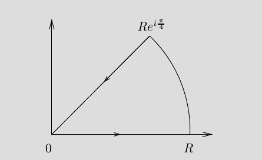

### 20.1.2 2.6.2

Show that

$$\begin{align*}
\int_{0}^{\infty} \frac{\sin x}{x} d x=\frac{\pi}{2}
.\end{align*}$$

> Hint: use the fact that this integral equals $\frac{1}{2 i} \int_{-\infty}^{\infty} \frac{e^{i x}-1}{x} d x$, and integrate around an indented semicircle.

### 20.1.3 2.6.5

Suppose $f\in C_{\mathbb{C}}^1(\Omega)$ and $T\subset \Omega$ is a triangle with $T^\circ \subset \Omega$. Apply Green’s theorem to show that $\int_T f(z) ~dz = 0$.

Assume that $f'$ is continuous and prove Goursat’s theorem.

> Hint: Green’s theorem states

$$\begin{align*}
\int_{T} F d x+G d y=\int_{T^\circ}\left(\frac{\partial G}{\partial x}-\frac{\partial F}{\partial y}\right) d x d y
.\end{align*}$$

### 20.1.4 2.6.6

Suppose that $f$ is holomorphic on a punctured open set $\Omega\setminus\left\{{w_0}\right\}$ and let $T\subset \Omega$ be a triangle containing $w_0$. Prove that if $f$ is bounded near $w_0$, then $\int_T f(z) ~dz = 0$.

### 20.1.5 2.6.7

Suppose $f: {\mathbb{D}}\to {\mathbb{C}}$ is holomorphic and let $d \mathrel{\vcenter{:}}=\sup_{z, w\in {\mathbb{D}}}{\left\lvert {f(z) - f(w)} \right\rvert}$ be the diameter of the image of $f$. Show that $2 {\left\lvert {f'(0)} \right\rvert} \leq d$, and that equality holds iff $f$ is linear, so $f(z) = a_1 z + a_2$.

> Hint: $2f'(0) = \frac{1}{2\pi i} \int_{{\left\lvert {\xi } \right\rvert}= r} \frac{ f(\xi) - f(-\xi) }{\xi^2} ~d\xi$ whenever $0<r<1$.

### 20.1.6 2.6.8

Suppose that $f$ is holomorphic on the strip $S = \left\{{x+iy {~\mathrel{\Big|}~}x\in {\mathbb{R}},~ -1<y<1}\right\}$ with ${\left\lvert {f(z)} \right\rvert} \leq A \qty{1 + {\left\lvert {z} \right\rvert}}^\nu$ for $\nu$ some fixed real number. Show that for all $z\in S$, for each integer $n\geq 0$ there exists an $A_n \geq 0$ such that ${\left\lvert {f^{(n)}(x)} \right\rvert} \leq A_n (1 + {\left\lvert {x} \right\rvert})^\nu$ for all $x\in {\mathbb{R}}$.

> Hint: Use the Cauchy inequalities.

### 20.1.7 2.6.9

Let $\Omega \subset {\mathbb{C}}$ be open and bounded and $\phi: \Omega \to \Omega$ holomorphic. Prove that if there exists a point $z_0 \in \Omega$ such that $\phi(z_0) = z_0$ and $\phi'(z_0) = 1$, then $\phi$ is linear.

> Hint: assume $z_0 = 0$ (explain why this can be done) and write $\phi(z) = z + a_n z^n + O(z^{n+1})$ near $0$. Let $\phi_k = \phi \circ \phi \circ \cdots \circ \phi$ and prove that $\phi_k(z) = z + ka_nz^n + O(z^{n+1})$. Apply Cauchy’s inequalities and let $k\to \infty$ to conclude.

### 20.1.8 2.6.10

Can every continuous function on $\mkern 1.5mu\overline{\mkern-1.5mu{\mathbb{D}}\mkern-1.5mu}\mkern 1.5mu$ be uniformly approximated by polynomials in the variable $z$?

> Hint: compare to Weierstrass for the real interval.

### 20.1.9 2.6.13

Suppose $f$ is analytic, defined on all of ${\mathbb{C}}$, and for each $z_0 \in {\mathbb{C}}$ there is at least one coefficient in the expansion $f(z) = \sum_{n=0}^\infty c_n(z-z_0)^n$ is zero. Prove that $f$ is a polynomial.

> Hint: use the fact that $c_n n! = f^{(n)}(z_0)$ and use a countability argument.

### 20.1.10 2.6.14

Suppose that $f$ is holomorphic in an open set containing ${\mathbb{D}}$ except for a pole $z_0 \in {{\partial}}{\mathbb{D}}$. Let $\sum_{n=0}^\infty a_n z^n$ be the power series expansion of $f$ in ${\mathbb{D}}$, and show that $\lim \frac{a_n}{a_{n+1}} = z_0$.

### 20.1.11 2.6.15

Suppose $f$ is continuous and nonvanishing on $\mkern 1.5mu\overline{\mkern-1.5mu{\mathbb{D}}\mkern-1.5mu}\mkern 1.5mu$, and holomorphic in ${\mathbb{D}}$. Prove that if ${\left\lvert {z} \right\rvert} = 1 \implies {\left\lvert {f(z)} \right\rvert} = 1$, then $f$ is constant.

> Hint: Extend $f$ to all of ${\mathbb{C}}$ by $f(z) = 1/ \mkern 1.5mu\overline{\mkern-1.5muf(1/\mkern 1.5mu\overline{\mkern-1.5muz\mkern-1.5mu}\mkern 1.5mu)\mkern-1.5mu}\mkern 1.5mu$ for any ${\left\lvert {z} \right\rvert} > 1$, and argue as in the Schwarz reflection principle.

## 20.2 Additional Problems

### 20.2.1 1

Let $a_n\neq 0$ and show that
$$\begin{align*}
\lim_{n\to \infty} {{\left\lvert {a_{n+1}} \right\rvert} \over {\left\lvert {a_n} \right\rvert}} = L \implies \lim_{n\to\infty} {\left\lvert {a_n} \right\rvert}^{1\over n} = L
.\end{align*}$$

In particular, this shows that when applicable, the ratio test can be used to calculate the radius of convergence of a power series.

### 20.2.2 2

Let $f$ be a power series centered at the origin. Prove that $f$ has a power series expansion about any point in its disc of convergence.

### 20.2.3 3

Prove the following:

1. $\sum_{n} nz^n$ does not converge at any point of $S^1$
2. $\sum_n {z^n \over n^2}$ converges at every point of $S^1$.
3. $\sum_n {z^n \over n}$ converges at every point of $S^1$ except $z=1$.

### 20.2.4 4

Without using Cauchy’s integral formula, show that if ${\left\lvert {a} \right\rvert} < r < {\left\lvert {b} \right\rvert}$, then
$$\begin{align*}
\int_{\gamma} \frac{d z}{(z-\alpha)(z-\beta)}=\frac{2 \pi i}{\alpha-\beta}
\end{align*}
where \(\gamma\) denotes the circle centered at the origin of radius \(r\) with positive orientation.$$

### 20.2.5 5

Assume $f$ is continuous in the region $\left\{{x+iy {~\mathrel{\Big|}~}x\geq x_0, ~ 0\leq y \leq b}\right\}$, and the following limit exists independent of $y$:
$$\begin{align*}
\lim_{x\to +\infty}f(x+iy) = A
.\end{align*}$$

Show that if $\gamma_x \mathrel{\vcenter{:}}=\left\{{z = x+it {~\mathrel{\Big|}~}0 \leq t \leq b}\right\}$, then
$$\begin{align*}
\lim_{x\to +\infty} \int_{\gamma_x} f(z) \,dz = iAb
.\end{align*}$$

### 20.2.6 6

Show by example that there exists a function $f(z)$ that is holomorphic on $\left\{{z\in {\mathbb{C}}{~\mathrel{\Big|}~}0 < {\left\lvert {z} \right\rvert} < 1}\right\}$ and for all $r<1$,
$$\begin{align*}
\int_{{\left\lvert {z} \right\rvert} = r} f(z) \, dz = 0
,\end{align*}
but \(f\) is not holomorphic at \(z=0\).$$

### 20.2.7 7

Let $f$ be analytic on a region $R$ and suppose $f'(z_0) \neq 0$ for some $z_0 \in R$. Show that if $C$ is a circle of sufficiently small radius centered at $z_0$, then
$$\begin{align*}
\frac{2 \pi i}{f^{\prime}\left(z_{0}\right)}=\int_{C} \frac{d z}{f(z)-f\left(z_{0}\right)}
.\end{align*}$$

> Hint: use the inverse function theorem.

### 20.2.8 8

Assume two functions $u, b: {\mathbb{R}}^2 \to {\mathbb{R}}$ have continuous partial derivatives at $(x_0 ,y_0)$. Show that $f \mathrel{\vcenter{:}}= u + iv$ has derivative $f'(z_0)$ at $z_0 = =x_0 + iy_0$ if and only if
$$\begin{align*}
\lim _{r \rightarrow 0} \frac{1}{\pi r^{2}} \int_{\left|z-z_{0}\right|=r} f(z) d z=0
.\end{align*}$$

### 20.2.9 9 (Cauchy’s Formula for Exterior Regions)

Let $\gamma$ be a piecewise smooth simple closed curve with interior $\Omega_1$ and exterior $\Omega_2$. Assume $f'$ exists in an open set containing $\gamma$ and $\Omega_2$ with $\lim_{z\to \infty} f(z) = A$. Show that
$$\begin{align*}
\frac{1}{2 \pi i} \int_{\gamma} \frac{f(\xi)}{\xi-z} d \xi=\left\{\begin{array}{ll}
A, & \text { if } z \in \Omega_{1} \\
-f(z)+A, & \text { if } z \in \Omega_{2}
\end{array}\right.
.\end{align*}$$

### 20.2.10 10

Let $f(z)$ be bounded and analytic in ${\mathbb{C}}$. Let $a\neq b$ be any fixed complex numbers. Show that the following limit exists:
$$\begin{align*}
\lim_{R\to \infty} \int_{{\left\lvert {z} \right\rvert} = R} {f(z) \over (z-a)(z-b)} \,dz
.\end{align*}$$

Use this to show that $f(z)$ must be constant.

### 20.2.11 11

Suppose $f(z)$ is entire and
$$\begin{align*}
\lim_{z\to\infty} {f(z) \over z} = 0
.\end{align*}$$

Show that $f(z)$ is a constant.

### 20.2.12 12

Let $f$ be analytic in a domain $D$ and $\gamma$ be a closed curve in $D$. For any $z_0\in D$ not on $\gamma$, show that
$$\begin{align*}
\int_{\gamma} \frac{f^{\prime}(z)}{\left(z-z_{0}\right)} d z=\int_{\gamma} \frac{f(z)}{\left(z-z_{0}\right)^{2}} d z
.\end{align*}
Give a generalization of this result.$$

### 20.2.13 13

Compute
$$\begin{align*}
\int_{{\left\lvert {z} \right\rvert} = 1} \qty{z + {1\over z}}^{2n} {dz \over z}
\end{align*}
and use it to show that
\begin{align*}
\int_0^{2\pi} \cos^{2n}(\theta) \, d\theta = 2\pi \qty{1\cdot 3 \cdot 5 \cdots (2n-1) \over 2 \cdot 4 \cdot 6 \cdots (2n)}
.\end{align*}$$

# 21 Spring 2020 Homework 3

## 21.1 Stein and Shakarchi

### 21.1.1 3.8.1

Use the following formula to show that the complex zeros of $\sin(\pi z)$ are exactly the integers, and they are each of order 1:
$$\begin{align*}
\sin \pi z=\frac{e^{i \pi z}-e^{-i \pi z}}{2 i}
.\end{align*}$$

Calculate the residue of ${1\over \sin(\pi z)}$ at $z=n\in {\mathbb{Z}}$.

### 21.1.2 3.8.2

Evaluate the integral
$$\begin{align*}
\int_{\mathbb{R}}{dx \over 1 + x^4}
.\end{align*}$$

What are the poles of ${1\over 1 + z^4}$ ?

### 21.1.3 3.8.4

Show that
$$\begin{align*}
\int_{-\infty}^{\infty} \frac{x \sin x}{x^{2}+a^{2}} d x=\pi e^{-a}, \quad \text { for all } a>0
.\end{align*}$$

### 21.1.4 3.8.5

Show that if $\xi\in {\mathbb{R}}$, then
$$\begin{align*}
\int_{-\infty}^{\infty} \frac{e^{-2 \pi i x \xi}}{\left(1+x^{2}\right)^{2}} d x=\frac{\pi}{2}(1+2 \pi|\xi|) e^{-2 \pi|\xi|}
.\end{align*}$$

### 21.1.5 3.8.6

Show that
$$\begin{align*}
\int_{-\infty}^{\infty} \frac{d x}{\left(1+x^{2}\right)^{n+1}}=\frac{1 \cdot 3 \cdot 5 \cdots(2 n-1)}{2 \cdot 4 \cdot 6 \cdots(2 n)} \cdot \pi
.\end{align*}$$

### 21.1.6 3.8.7

Show that
$$\begin{align*}
\int_{0}^{2 \pi} \frac{d \theta}{(a+\cos \theta)^{2}}=\frac{2 \pi a}{\left(a^{2}-1\right)^{3 / 2}}, \quad \text { whenever } a>1
.\end{align*}$$

### 21.1.7 3.8.8

Show that if $a,b\in {\mathbb{R}}$ with $a > {\left\lvert {b} \right\rvert}$, then
$$\begin{align*}
\int_{0}^{2 \pi} \frac{d \theta}{a+b \cos \theta}=\frac{2 \pi}{\sqrt{a^{2}-b^{2}}}
.\end{align*}$$

### 21.1.8 3.8.9

Show that
$$\begin{align*}
\int_{0}^{1} \log (\sin \pi x) d x=-\log 2
.\end{align*}$$

> Hint: use the following contour.

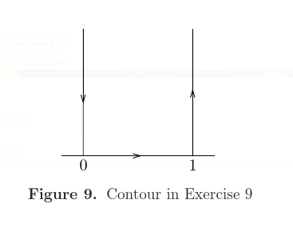

### 21.1.9 3.8.10

Show that if $a>0$, then
$$\begin{align*}
\int_{0}^{\infty} \frac{\log x}{x^{2}+a^{2}} d x=\frac{\pi}{2 a} \log a
.\end{align*}$$

> Hint: use the following contour.

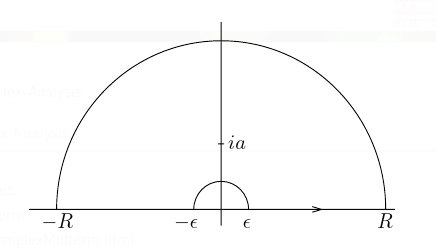

### 21.1.10 3.8.14

Prove that all entire functions that are injective are of the form $f(z) = az + b$ with $a,b\in {\mathbb{C}}$ and $a\neq 0$.

> Hint: Apply the Casorati-Weierstrass theorem to $f(1/z)$.

### 21.1.11 3.8.15

Use the Cauchy inequalities or the maximum modulus principle to solve the following problems:

1. Prove that if $f$ is an entire function that satisfies
   $$\begin{align*}
   \sup _{|z|=R}|f(z)| \leq A R^{k}+B
   \end{align*}
   for all \(R>0\), some integer \(k\geq 0\), and some constants \(A, B > 0\), then \(f\) is a polynomial of degree \(\leq k\).$$
2. Show that if $f$ is holomorphic in the unit disc, is bounded, and converges uniformly to zero in the sector $\theta < \arg(z) < \phi$ as ${\left\lvert {z} \right\rvert} \to 0$, then $f \equiv 0$.
3. Let $w_1, \cdots w_n$ be points on $S^1 \subset {\mathbb{C}}$. Prove that there exists a point $z\in S^1$ such that the product of the distances from $z$ to the points $w_j$ is at least 1.

   Conclude that there exists a point $w\in S^1$ such that the product of the above distances is *exactly* 1.
4. Show that if the real part of an entire function is bounded, then $f$ is constant.

### 21.1.12 3.8.17

Let $f$ be non-constant and holomorphic in an open set containing the closed unit disc.

1. Show that if ${\left\lvert {f(z)} \right\rvert} = 1$ whenever ${\left\lvert {z} \right\rvert} = 1$, then the image of $f$ contains the unit disc.

   > Hint: Show that $f(z) = w_0$ has a root for every $w_0 \in {\mathbb{D}}$, for which it suffices to show that $f(z) = 0$ has a root. Conclude using the maximum modulus principle.
2. If ${\left\lvert {f(z)} \right\rvert} \geq 1$ whenever ${\left\lvert {z} \right\rvert} = 1$ and there exists a $z_0\in {\mathbb{D}}$ such that ${\left\lvert {f(z_0)} \right\rvert} < 1$, then the image of $f$ contains the unit disc.

### 21.1.13 3.8.19

Prove that maximum principle for harmonic functions, i.e.

1. If $u$ is a non-constant real-valued harmonic function in a region $\Omega$, then $u$ can not attain a maximum or a minimum in $\Omega$.
2. Suppose $\Omega$ is a region with compact closure $\mkern 1.5mu\overline{\mkern-1.5mu\Omega\mkern-1.5mu}\mkern 1.5mu$. If $u$ is harmonic in $\Omega$ and continuous in $\mkern 1.5mu\overline{\mkern-1.5mu\Omega\mkern-1.5mu}\mkern 1.5mu$, then
   $$\begin{align*}
   \sup _{z \in \Omega}|u(z)| \leq \sup _{z \in \mkern 1.5mu\overline{\mkern-1.5mu\Omega \mkern-1.5mu}\mkern 1.5mu-\Omega}|u(z)|
   .\end{align*}$$

> Hint: to prove (a), assume $u$ attains a local maximum at $z_0$. Let $f$ be holomorphic near $z_0$ with $\Re(f) = u$, and show that $f$ is not an open map. Then (a) implies (b).

## 21.2 Extra Problems

### 21.2.1 1

**Problem**

Prove that if $f$ has two Laurent series expansions,
$$\begin{align*}
f(z) = \sum c_n(z-a)^n \quad\text{and}\quad f(z) = \sum c_n'(z-a)^n
\end{align*}
then \(c_n = c_n'\).$$

### 21.2.2 2

**Problem**

Find Laurent series expansions of
$$\begin{align*}
\frac{1}{1-z^2} + \frac{1}{3-z}
\end{align*}
How many such expansions are there? In what domains are each valid?$$

### 21.2.3 3

**Problem**

Let $P, Q$ be polynomials with no common zeros. Assume $a$ is a root of $Q$. Find the principal part of $P/Q$ at $z=a$ in terms of $P$ and $Q$ if $a$ is (1) a simple root, and (2) a double root.

### 21.2.4 4

**Problem**

Let $f$ be non-constant, analytic in ${\left\lvert {z} \right\rvert} > 0$, where $f(z_n) = 0$ for infinitely many points $z_n$ with $\lim_{n\to\infty} z_n = 0$.

Show that $z=0$ is an essential singularity for $f$.

> Example: $f(z) = \sin(1/z)$.

### 21.2.5 5

**Problem**

Show that if $f$ is entire and $\lim_{z\to\infty}f(z) = \infty$, then $f$ is a polynomial.

### 21.2.6 6

**Problem**

1. Show (without using 3.8.9 in the S&S) that
   $$\begin{align*}
   \int_0^{2\pi} \log{\left\lvert {1 - e^{i\theta}} \right\rvert}~d\theta = 0
   \end{align*}$$
2. Show that this identity is equivalent to S&S 3.8.9:
   $$\begin{align*}
   \int_0^1 \log(\sin(\pi x)) ~dx = -\log 2
   .\end{align*}$$

### 21.2.7 7

**Problem**

Let $0<a<4$ and evaluate
$$\begin{align*}
\int_0^\infty \frac{x^{\alpha-1}}{1+x^3} ~dx
\end{align*}$$

### 21.2.8 8

**Problem**

Prove the fundamental theorem of Algebra using

1. Rouche’s Theorem.
2. The maximum modulus principle.

### 21.2.9 9

**Problem**

Let $f$ be analytic in a region $D$ and $\gamma$ a rectifiable curve in $D$ with interior in $D$.

Prove that if $f(z)$ is real for all $z\in \gamma$, then $f$ is constant.

### 21.2.10 10

**Problem**

For $a> 0$, evaluate
$$\begin{align*}
\int_0^{\pi/2} \frac{d\theta}{a + \sin^2 \theta}
\end{align*}$$

### 21.2.11 11

**Problem**

Find the number of roots of $p(z) = 4z^4 - 6z + 3$ in ${\left\lvert {z} \right\rvert} < 1$ and $1 < {\left\lvert {z} \right\rvert} < 2$ respectively.

### 21.2.12 12

**Problem**

Prove that $z^4 + 2z^3 -2z + 10$ has exactly one root in each open quadrant.

### 21.2.13 13

**Problem**

Prove that for $a> 0$, $z\tan z - a$ has only real roots.

### 21.2.14 14

**Problem**

Let $f$ be nonzero, analytic on a bounded region $\Omega$ and continuous on its closure $\overline \Omega$.

Show that if ${\left\lvert {f(z)} \right\rvert} \equiv M$ is constant for $z\in \partial \Omega$, then $f(z) \equiv Me^{i\theta}$ for some real constant $\theta$.

# 22 Extra Questions from Jingzhi Tie

## 22.1 Fall 2009

### 22.1.1 ?

1. Assume $\displaystyle f(z) = \sum_{n=0}^\infty c_n z^n$ converges in $|z| < R$. Show that for $r <R$,
   $$\begin{align*}\frac{1}{2 \pi} \int_0^{2 \pi} |f(r e^{i \theta})|^2 d \theta =
   \sum_{n=0}^\infty |c_n|^2 r^{2n} \; .\end{align*}$$
2. Deduce Liouville’s theorem from (1).

### 22.1.2 ?

Let $f$ be a continuous function in the region
$$\begin{align*}D=\{z {~\mathrel{\Big|}~}{\left\lvert {z} \right\rvert}>R, 0\leq \arg z\leq \theta\}\quad\text{where}\quad
1\leq \theta \leq 2\pi.\end{align*}
If there exists \(k\) such that \(\displaystyle{\lim_{z\to\infty} zf(z)=k}\) for \(z\) in the region \(D\). Show that
\begin{align*}\lim_{R'\to\infty} \int_{L} f(z) dz=i\theta k,\end{align*}
where \(L\) is the part of the circle \(|z|=R'\) which lies in the region \(D\).$$

### 22.1.3 ?

Suppose that $f$ is an analytic function in the region $D$ which contains the point $a$. Let
$$\begin{align*}F(z)= z-a-qf(z),\quad \text{where}~ q \ \text{is a complex
parameter}.\end{align*}$$

1. Let $K\subset D$ be a circle with the center at point $a$ and also we assume that $f(z)\not =0$ for $z\in K$. Prove that the function $F$ has one and only one zero $z=w$ on the closed disc $\mkern 1.5mu\overline{\mkern-1.5muK\mkern-1.5mu}\mkern 1.5mu$ whose boundary is the circle $K$ if $\displaystyle{ |q|<\min_{z\in K} \frac{|z-a|}{|f(z)|}.}$
2. Let $G(z)$ be an analytic function on the disk $\mkern 1.5mu\overline{\mkern-1.5muK\mkern-1.5mu}\mkern 1.5mu$. Apply the residue theorem to prove that $\displaystyle{ \frac{G(w)}{F'(w)}=\frac{1}{2\pi i}\int_K \frac{G(z)}{F(z)} dz,}$ where $w$ is the zero from (1).
3. If $z\in K$, prove that the function $\displaystyle{\frac{1}{F(z)}}$ can be represented as a convergent series with respect to $q$: $\displaystyle{ \frac{1}{F(z)}=\sum_{n=0}^{\infty} \frac{(qf(z))^n}{(z-a)^{n+1}}.}$

### 22.1.4 ?

Evaluate
$$\begin{align*}\displaystyle{ \int_{0}^{\infty}\frac{x\sin x}{x^2+a^2} \,
dx }.\end{align*}$$

### 22.1.5 ?

Let $f=u+iv$ be differentiable (i.e. $f'(z)$ exists) with continuous partial derivatives at a point $z=re^{i\theta}$, $r\not= 0$. Show that
$$\begin{align*}\frac{\partial u}{\partial r}=\frac{1}{r}\frac{\partial v}{\partial \theta},\quad
\frac{\partial v}{\partial r}=-\frac{1}{r}\frac{\partial u}{\partial \theta}.\end{align*}$$

### 22.1.6 ?

Show that $\displaystyle \int_0^\infty \frac{x^{a-1}}{1+x^n} dx=\frac{\pi}{n\sin \frac{a\pi}{n}}$ using complex analysis, $0< a < n$. Here $n$ is a positive integer.

### 22.1.7 ?

For $s>0$, the **gamma function** is defined by $\displaystyle{\Gamma(s)=\int_0^{\infty} e^{-t}t^{s-1} dt}$.

1. Show that the gamma function is analytic in the half-plane $\Re (s)>0$, and is still given there by the integral formula above.
2. Apply the formula in the previous question to show that
   $$\begin{align*}\Gamma(s)\Gamma(1-s)=\frac{\pi}{\sin \pi s}.\end{align*}$$

> Hint: You may need $\displaystyle{\Gamma(1-s)=t \int_0^{\infty}e^{-vt}(vt)^{-s} dv}$ for $t>0$.

### 22.1.8 ?

Apply Rouché’s Theorem to prove the Fundamental Theorem of Algebra: If
$$\begin{align*}P_n(z) = a_0 + a_1z + \cdots + a_{n-1}z^{n-1} + a_nz^n\quad (a_n \neq 0)\end{align*}
is a polynomial of degree n, then it has n zeros in \(\mathbb C\).$$

### 22.1.9 ?

Suppose $f$ is entire and there exist $A, R >0$ and natural number $N$ such that
$$\begin{align*}|f(z)| \geq A |z|^N\ \text{for}\ |z| \geq R.\end{align*}
Show that (i) \(f\) is a polynomial and (ii) the degree of \(f\) is at least \(N\).$$

### 22.1.10 ?

Let $f: {\mathbb C} \rightarrow {\mathbb C}$ be an injective analytic (also called *univalent*) function. Show that there exist complex numbers $a \neq 0$ and $b$ such that $f(z) = az + b$.

### 22.1.11 ?

Let $g$ be analytic for $|z|\leq 1$ and $|g(z)| < 1$ for $|z| = 1$.

1. Show that $g$ has a unique fixed point in $|z| < 1$.
2. What happens if we replace $|g(z)| < 1$ with $|g(z)|\leq 1$ for $|z|=1$? Give an example if (a) is not true or give an proof if (a) is still true.
3. What happens if we simply assume that $f$ is analytic for $|z| < 1$ and $|f(z)| < 1$ for $|z| < 1$? Suppose that $f(z) \not\equiv z$. Can f have more than one fixed point in $|z| < 1$?

> Hint: The map $\displaystyle{\psi_{\alpha}(z)=\frac{\alpha-z}{1-\mkern 1.5mu\overline{\mkern-1.5mu\alpha\mkern-1.5mu}\mkern 1.5muz}}$ may be useful.

### 22.1.12 ?

Find a conformal map from $D = \{z :\ |z| < 1,\ |z - 1/2| > 1/2\}$ to the unit disk $\Delta=\{z: \ |z|<1\}$.

### 22.1.13 ?

Let $f(z)$ be entire and assume values of $f(z)$ lie outside a *bounded* open set $\Omega$. Show without using Picard’s theorems that $f(z)$ is a constant.

### 22.1.14 ?

1. Assume $\displaystyle f(z) = \sum_{n=0}^\infty c_n z^n$ converges in $|z| < R$. Show that for $r <R$,
   $$\begin{align*}\frac{1}{2 \pi} \int_0^{2 \pi} |f(r e^{i \theta})|^2 d \theta
   = \sum_{n=0}^\infty |c_n|^2 r^{2n} \; .\end{align*}$$
2. Deduce Liouville’s theorem from (1).

### 22.1.15 ?

Let $f(z)$ be entire and assume that $f(z) \leq M |z|^2$ outside some disk for some constant $M$. Show that $f(z)$ is a polynomial in $z$ of degree $\leq 2$.

### 22.1.16 ?

Let $a_n(z)$ be an analytic sequence in a domain $D$ such that $\displaystyle \sum_{n=0}^\infty |a_n(z)|$ converges uniformly on bounded and closed sub-regions of $D$. Show that $\displaystyle \sum_{n=0}^\infty |a'_n(z)|$ converges uniformly on bounded and closed sub-regions of $D$.

### 22.1.17 ?

Let $f(z)$ be analytic in an open set $\Omega$ except possibly at a point $z_0$ inside $\Omega$. Show that if $f(z)$ is bounded in near $z_0$, then $\displaystyle \int_\Delta f(z) dz = 0$ for all triangles $\Delta$ in $\Omega$.

### 22.1.18 ?

Assume $f$ is continuous in the region: $0< |z-a| \leq R, \; 0 \leq \arg(z-a) \leq \beta_0$ ($0 < \beta_0 \leq 2 \pi$) and the limit $\displaystyle \lim_{z \rightarrow a} (z-a) f(z) = A$ exists. Show that
$$\begin{align*}\lim_{r \rightarrow 0} \int_{\gamma_r} f(z) dz = i A \beta_0 \; , \; \;\end{align*}
where \(\gamma_r : = \{ z \; | \; z = a + r e^{it}, \; 0 \leq t \leq \beta_0 \}.$$

### 22.1.19 ?

Show that $f(z) = z^2$ is uniformly continuous in any open disk $|z| < R$, where $R>0$ is fixed, but it is not uniformly continuous on $\mathbb C$.

### 22.1.20 ?

1. Show that the function $u=u(x,y)$ given by
   $$\begin{align*}u(x,y)=\frac{e^{ny}-e^{-ny}}{2n^2}\sin nx\quad \text{for}\ n\in {\mathbf N}\end{align*}
   is the solution on \(D=\{(x,y)\ | x^2+y^2<1\}\) of the Cauchy problem for the Laplace equation
   \begin{align*}\frac{\partial ^2u}{\partial x^2}+\frac{\partial ^2u}{\partial y^2}=0,\quad
   u(x,0)=0,\quad \frac{\partial u}{\partial y}(x,0)=\frac{\sin nx}{n}.\end{align*}$$
2. Show that there exist points $(x,y)\in D$ such that $\displaystyle{\limsup_{n\to\infty} |u(x,y)|=\infty}$.

## 22.2 Fall 2011

### 22.2.1 ?

1. Assume $\displaystyle f(z) = \sum_{n=0}^\infty c_n z^n$ converges in $|z| < R$. Show that for $r <R$,
   $$\begin{align*}\frac{1}{2 \pi} \int_0^{2 \pi} |f(r e^{i \theta})|^2 d \theta =
   \sum_{n=0}^\infty |c_n|^2 r^{2n} \; .\end{align*}$$
2. Deduce Liouville’s theorem from (1).

### 22.2.2 ?

Let $f$ be a continuous function in the region
$$\begin{align*}D=\{z\ | |z|>R, 0\leq \arg Z\leq \theta\}\quad\text{where}\quad
0\leq \theta \leq 2\pi.\end{align*}
If there exists \(k\) such that \(\displaystyle{\lim_{z\to\infty} zf(z)=k}\) for \(z\) in the region \(D\). Show that
\begin{align*}\lim_{R'\to\infty} \int_{L} f(z) dz=i\theta k,\end{align*}
where \(L\) is the part of the circle \(|z|=R'\) which lies in the region \(D\).$$

### 22.2.3 ?

Suppose that $f$ is an analytic function in the region $D$ which contains the point $a$. Let
$$\begin{align*}F(z)= z-a-qf(z),\quad \text{where}\quad q \ \text{is a complex
parameter}.\end{align*}$$

1. Let $K\subset D$ be a circle with the center at point $a$ and also we assume that $f(z)\not =0$ for $z\in K$. Prove that the function $F$ has one and only one zero $z=w$ on the closed disc $\mkern 1.5mu\overline{\mkern-1.5muK\mkern-1.5mu}\mkern 1.5mu$ whose boundary is the circle $K$ if $\displaystyle{ |q|<\min_{z\in K} \frac{|z-a|}{|f(z)|}.}$
2. Let $G(z)$ be an analytic function on the disk $\mkern 1.5mu\overline{\mkern-1.5muK\mkern-1.5mu}\mkern 1.5mu$. Apply the residue theorem to prove that $\displaystyle{ \frac{G(w)}{F'(w)}=\frac{1}{2\pi i}\int_K \frac{G(z)}{F(z)} dz,}$ where $w$ is the zero from (1).
3. If $z\in K$, prove that the function $\displaystyle{\frac{1}{F(z)}}$ can be represented as a convergent series with respect to $q$: $\displaystyle{ \frac{1}{F(z)}=\sum_{n=0}^{\infty} \frac{(qf(z))^n}{(z-a)^{n+1}}.}$

### 22.2.4 ?

Evaluate $\displaystyle{ \int_{0}^{\infty}\frac{x\sin x}{x^2+a^2} \, dx }$.

### 22.2.5 ?

Let $f=u+iv$ be differentiable (i.e. $f'(z)$ exists) with continuous partial derivatives at a point $z=re^{i\theta}$, $r\not= 0$. Show that
$$\begin{align*}\frac{\partial u}{\partial r}=\frac{1}{r}\frac{\partial v}{\partial \theta},\quad
\frac{\partial v}{\partial r}=-\frac{1}{r}\frac{\partial u}{\partial \theta}.\end{align*}$$

### 22.2.6 ?

Show that $\displaystyle \int_0^\infty \frac{x^{a-1}}{1+x^n} dx=\frac{\pi}{n\sin \frac{a\pi}{n}}$ using complex analysis, $0< a < n$. Here $n$ is a positive integer.

### 22.2.7 ?

For $s>0$, the **gamma function** is defined by $\displaystyle{\Gamma(s)=\int_0^{\infty} e^{-t}t^{s-1} dt}$.

1. Show that the gamma function is analytic in the half-plane $\Re (s)>0$, and is still given there by the integral formula above.
2. Apply the formula in the previous question to show that
   $$\begin{align*}\Gamma(s)\Gamma(1-s)=\frac{\pi}{\sin \pi s}.\end{align*}$$

> Hint: You may need $\displaystyle{\Gamma(1-s)=t \int_0^{\infty}e^{-vt}(vt)^{-s} dv}$ for $t>0$.

### 22.2.8 ?

Apply Rouché’s Theorem to prove the Fundamental Theorem of Algebra: If
$$\begin{align*}P_n(z) = a_0 + a_1z + \cdots + a_{n-1}z^{n-1} + a_nz^n\quad (a_n \neq 0)\end{align*}
is a polynomial of degree n, then it has n zeros in \(\mathbb C\).$$

### 22.2.9 ?

Suppose $f$ is entire and there exist $A, R >0$ and natural number $N$ such that
$$\begin{align*}|f(z)| \geq A |z|^N\ \text{for}\ |z| \geq R.\end{align*}
Show that (i) \(f\) is a polynomial and (ii) the degree of \(f\) is at least \(N\).$$

### 22.2.10 ?

Let $f: {\mathbb C} \rightarrow {\mathbb C}$ be an injective analytic (also called univalent) function. Show that there exist complex numbers $a \neq 0$ and $b$ such that $f(z) = az + b$.

### 22.2.11 ?

Let $g$ be analytic for $|z|\leq 1$ and $|g(z)| < 1$ for $|z| = 1$.

- Show that $g$ has a unique fixed point in $|z| < 1$.
- What happens if we replace $|g(z)| < 1$ with $|g(z)|\leq 1$ for $|z|=1$? Give an example if (a) is not true or give an proof if (a) is still true.
- What happens if we simply assume that $f$ is analytic for $|z| < 1$ and $|f(z)| < 1$ for $|z| < 1$? Suppose that $f(z) \not\equiv z$. Can f have more than one fixed point in $|z| < 1$?

> Hint: The map $\displaystyle{\psi_{\alpha}(z)=\frac{\alpha-z}{1-\mkern 1.5mu\overline{\mkern-1.5mu\alpha\mkern-1.5mu}\mkern 1.5muz}}$ may be useful.

### 22.2.12 ?

Find a conformal map from $D = \{z :\ |z| < 1,\ |z - 1/2| > 1/2\}$ to the unit disk $\Delta=\{z: \ |z|<1\}$.

### 22.2.13 ?

Let $f(z)$ be entire and assume values of $f(z)$ lie outside a *bounded* open set $\Omega$. Show without using Picard’s theorems that $f(z)$ is a constant.

### 22.2.14 ?

Let $f(z)$ be entire and assume values of $f(z)$ lie outside a *bounded* open set $\Omega$. Show without using Picard’s theorems that $f(z)$ is a constant.

### 22.2.15 ?

1. Assume $\displaystyle f(z) = \sum_{n=0}^\infty c_n z^n$ converges in $|z| < R$. Show that for $r <R$,
   $$\begin{align*}\frac{1}{2 \pi} \int_0^{2 \pi} |f(r e^{i \theta})|^2 d \theta
   = \sum_{n=0}^\infty |c_n|^2 r^{2n} \; .\end{align*}$$
2. Deduce Liouville’s theorem from (1).

### 22.2.16 ?

Let $f(z)$ be entire and assume that $f(z) \leq M |z|^2$ outside some disk for some constant $M$. Show that $f(z)$ is a polynomial in $z$ of degree $\leq 2$.

### 22.2.17 ?

Let $a_n(z)$ be an analytic sequence in a domain $D$ such that $\displaystyle \sum_{n=0}^\infty |a_n(z)|$ converges uniformly on bounded and closed sub-regions of $D$. Show that $\displaystyle \sum_{n=0}^\infty |a'_n(z)|$ converges uniformly on bounded and closed sub-regions of $D$.

### 22.2.18 ?

Let $f(z)$ be analytic in an open set $\Omega$ except possibly at a point $z_0$ inside $\Omega$. Show that if $f(z)$ is bounded in near $z_0$, then $\displaystyle \int_\Delta f(z) dz = 0$ for all triangles $\Delta$ in $\Omega$.

### 22.2.19 ?

Assume $f$ is continuous in the region: $0< |z-a| \leq R, \; 0 \leq \arg(z-a) \leq \beta_0$ ($0 < \beta_0 \leq 2 \pi$) and the limit $\displaystyle \lim_{z \rightarrow a} (z-a) f(z) = A$ exists. Show that
$$\begin{align*}\lim_{r \rightarrow 0} \int_{\gamma_r} f(z) dz = i A \beta_0 \; , \; \;\end{align*}
where \(\gamma_r : = \{ z \; | \; z = a + r e^{it}, \; 0 \leq t \leq \beta_0 \}.$$

### 22.2.20 ?

Show that $f(z) = z^2$ is uniformly continuous in any open disk $|z| < R$, where $R>0$ is fixed, but it is not uniformly continuous on $\mathbb C$.

1. Show that the function $u=u(x,y)$ given by
   $$\begin{align*}u(x,y)=\frac{e^{ny}-e^{-ny}}{2n^2}\sin nx\quad \text{for}\ n\in {\mathbf N}\end{align*}
   is the solution on \(D=\{(x,y)\ | x^2+y^2<1\}\) of the Cauchy problem for the Laplace equation
   \begin{align*}\frac{\partial ^2u}{\partial x^2}+\frac{\partial ^2u}{\partial y^2}=0,\quad
   u(x,0)=0,\quad \frac{\partial u}{\partial y}(x,0)=\frac{\sin nx}{n}.\end{align*}$$
2. Show that there exist points $(x,y)\in D$ such that $\displaystyle{\limsup_{n\to\infty} |u(x,y)|=\infty}$.

## 22.3 Spring 2014

### 22.3.1 ?

The question provides some insight into Cauchy’s theorem. Solve the problem without using the Cauchy theorem.

1. Evaluate the integral $\displaystyle{\int_{\gamma} z^n dz}$ for all integers $n$. Here $\gamma$ is any circle centered at the origin with the positive (counterclockwise) orientation.
2. Same question as (a), but with $\gamma$ any circle not containing the origin.
3. Show that if $|a|<r<|b|$, then $\displaystyle{\int_{\gamma}\frac{dz}{(z-a)(z-b)} dz=\frac{2\pi i}{a-b}}$. Here $\gamma$ denotes the circle centered at the origin, of radius $r$, with the positive orientation.

### 22.3.2 ?

1. Assume the infinite series $\displaystyle \sum_{n=0}^\infty c_n z^n$ converges in $|z| < R$ and let $f(z)$ be the limit. Show that for $r <R$,
   $$\begin{align*}\frac{1}{2 \pi} \int_0^{2 \pi} |f(r e^{i \theta})|^2 d \theta =
   \sum_{n=0}^\infty |c_n|^2 r^{2n} \; .\end{align*}$$
2. Deduce Liouville’s theorem from (1). Liouville’s theorem: If $f(z)$ is entire and bounded, then $f$ is constant.

### 22.3.3 ?

Let $f$ be a continuous function in the region
$$\begin{align*}D=\{z\ | |z|>R, 0\leq \arg Z\leq \theta\}\quad\text{where}\quad
0\leq \theta \leq 2\pi.\end{align*}
If there exists \(k\) such that \(\displaystyle{\lim_{z\to\infty} zf(z)=k}\) for \(z\) in the region \(D\). Show that
\begin{align*}\lim_{R'\to\infty} \int_{L} f(z) dz=i\theta k,\end{align*}
where \(L\) is the part of the circle \(|z|=R'\) which lies in the region \(D\).$$

### 22.3.4 ?

Evaluate $\displaystyle{ \int_{0}^{\infty}\frac{x\sin x}{x^2+a^2} \, dx }$.

### 22.3.5 ?

Let $f=u+iv$ be differentiable (i.e. $f'(z)$ exists) with continuous partial derivatives at a point $z=re^{i\theta}$, $r\not= 0$. Show that
$$\begin{align*}\frac{\partial u}{\partial r}=\frac{1}{r}\frac{\partial v}{\partial \theta},\quad
\frac{\partial v}{\partial r}=-\frac{1}{r}\frac{\partial u}{\partial \theta}.\end{align*}$$

### 22.3.6 ?

Show that $\displaystyle \int_0^\infty \frac{x^{a-1}}{1+x^n} dx=\frac{\pi}{n\sin \frac{a\pi}{n}}$ using complex analysis, $0< a < n$. Here $n$ is a positive integer.

### 22.3.7 ?

For $s>0$, the **gamma function** is defined by $\displaystyle{\Gamma(s)=\int_0^{\infty} e^{-t}t^{s-1} dt}$.

- Show that the gamma function is analytic in the half-plane $\Re (s)>0$, and is still given there by the integral formula above.
- Apply the formula in the previous question to show that
  $$\begin{align*}\Gamma(s)\Gamma(1-s)=\frac{\pi}{\sin \pi s}.\end{align*}$$

> Hint: You may need $\displaystyle{\Gamma(1-s)=t \int_0^{\infty}e^{-vt}(vt)^{-s} dv}$ for $t>0$.

### 22.3.8 ?

Apply Rouché’s Theorem to prove the Fundamental Theorem of Algebra: If
$$\begin{align*}P_n(z) = a_0 + a_1z + \cdots + a_{n-1}z^{n-1} + a_nz^n\quad (a_n \neq 0)\end{align*}
is a polynomial of degree n, then it has n zeros in \(\mathbf C\).$$

### 22.3.9 ?

Suppose $f$ is entire and there exist $A, R >0$ and natural number $N$ such that
$$\begin{align*}|f(z)| \geq A |z|^N\ \text{for}\ |z| \geq R.\end{align*}
Show that (i) \(f\) is a polynomial and (ii) the degree of \(f\) is at least \(N\).$$

### 22.3.10 ?

Let $f: {\mathbb C} \rightarrow {\mathbb C}$ be an injective analytic (also called univalent) function. Show that there exist complex numbers $a \neq 0$ and $b$ such that $f(z) = az + b$.

### 22.3.11 ?

Let $g$ be analytic for $|z|\leq 1$ and $|g(z)| < 1$ for $|z| = 1$.

- Show that $g$ has a unique fixed point in $|z| < 1$.
- What happens if we replace $|g(z)| < 1$ with $|g(z)|\leq 1$ for $|z|=1$? Give an example if (a) is not true or give an proof if (a) is still true.
- What happens if we simply assume that $f$ is analytic for $|z| < 1$ and $|f(z)| < 1$ for $|z| < 1$? Suppose that $f(z) \not\equiv z$. Can f have more than one fixed point in $|z| < 1$?

> Hint: The map $\displaystyle{\psi_{\alpha}(z)=\frac{\alpha-z}{1-\mkern 1.5mu\overline{\mkern-1.5mu\alpha\mkern-1.5mu}\mkern 1.5muz}}$ may be useful.

### 22.3.12 ?

Find a conformal map from $D = \{z :\ |z| < 1,\ |z - 1/2| > 1/2\}$ to the unit disk $\Delta=\{z: \ |z|<1\}$.

## 22.4 Fall 2015

### 22.4.2 ?

> Hint: Calculate $F \circ F$.

### 22.4.3 ?

Use $n$-th roots of unity (i.e. solutions of $z^n - 1 =0$) to show that
$$\begin{align*}2^{n-1} \sin\frac{\pi}{n} \sin\frac{2\pi}{n} \cdots \sin\frac{(n-1)\pi}{n}
= n
\; .\end{align*}$$

$$\begin{align*}\frac{\partial u}{\partial r} = \frac{1}{r} \frac{\partial v}{\partial \theta}
\; \; \; \text{and} \; \; \;
\frac{\partial v}{\partial r} = - \frac{1}{r} \frac{\partial u}{\partial \theta}\end{align*}$$

2. Use these equations to show that the logarithm function defined by
   $$\begin{align*}\log z = \log r + i \theta \; \;
   \mbox{where} \; z = r e^{i \theta } \; \mbox{with} \; - \pi < \theta < \pi\end{align*}
   is a holomorphic function in the region \(r>0, \; - \pi < \theta < \pi\). Also show that \(\log z\) defined above is not continuous in \(r>0\).$$

### 22.4.4 ?

Assume $f$ is continuous in the region: $x \geq x_0, \; 0 \leq y \leq b$ and the limit
$$\begin{align*}\displaystyle \lim_{x \rightarrow + \infty} f(x + iy) = A\end{align*}
exists uniformly with respect to \(y\) (independent of \(y\)). Show that
\begin{align*}\lim_{x \rightarrow + \infty} \int_{\gamma_x} f(z) dz = iA b \; , \; \;\end{align*}
where \(\gamma_x : = \{ z \; | \; z = x + it, \; 0 \leq t \leq b\}.$$

### 22.4.5 ?

(Cauchy’s formula for “exterior” region) Let $\gamma$ be piecewise smooth simple closed curve with interior $\Omega_1$ and exterior $\Omega_2$. Assume $f'(z)$ exists in an open set containing $\gamma$ and $\Omega_2$ and $\lim_{z \rightarrow \infty } f(z) = A$. Show that
$$\begin{align*}\frac{1}{2 \pi i} \int_\gamma \frac{f(\xi)}{\xi - z} \, d \xi =
\begin{cases}
A, & \text{if\ $z \in \Omega_1$}, \\
-f (z) + A, & \text{if\ $z \in \Omega_2$}
\end{cases}\end{align*}$$

### 22.4.6 ?

Let $f(z)$ be bounded and analytic in $\mathbb C$. Let $a \neq b$ be any fixed complex numbers. Show that the following limit exists
$$\begin{align*}\lim_{R \rightarrow \infty} \int_{|z|=R} \frac{f(z)}{(z-a)(z-b)} dz.\end{align*}
Use this to show that \(f(z)\) must be a constant (Liouville’s theorem).$$

### 22.4.7 ?

Prove by *justifying all steps* that for all $\xi \in {\mathbb C}$ we have $\displaystyle e^{- \pi \xi^2} = \int_{- \infty}^\infty e^{- \pi x^2} e^{2 \pi i x \xi} dx \; .$

> Hint: You may use that fact in Example 1 on p. 42 of the textbook without proof, i.e., you may assume the above is true for real values of $\xi$.

### 22.4.9 ?

Let $f(z)$ be a non-constant analytic function in $|z|>0$ such that $f(z_n) = 0$ for infinite many points $z_n$ with $\lim_{n \rightarrow \infty} z_n =0$. Show that $z=0$ is an essential singularity for $f(z)$. (An example of such a function is $f(z) = \sin (1/z)$.)

### 22.4.10 ?

Let $f$ be entire and suppose that $\lim_{z \rightarrow \infty} f(z) = \infty$. Show that $f$ is a polynomial.

### 22.4.11 ?

Expand the following functions into Laurent series in the indicated regions:

1. $\displaystyle f(z) = \frac{z^2 - 1}{ (z+2)(z+3)}, \; \; 2 < |z| < 3$, $3 < |z| < + \infty$.
2. $\displaystyle f(z) = \sin \frac{z}{1-z}, \; \; 0 < |z-1| < + \infty$

### 22.4.12 ?

Assume $f(z)$ is analytic in region $D$ and $\Gamma$ is a rectifiable curve in $D$ with interior in $D$. Prove that if $f(z)$ is real for all $z \in \Gamma$, then $f(z)$ is a constant.

### 22.4.13 ?

Find the number of roots of $z^4 - 6z + 3 =0$ in $|z|<1$ and $1 < |z| < 2$ respectively.

### 22.4.14 ?

Prove that $z^4 + 2 z^3 - 2z + 10 =0$ has exactly one root in each open quadrant.

### 22.4.15 ?

1. Let $f(z) \in H({\mathbb D})$, $\text{Re}(f(z)) >0$, $f(0)= a>0$. Show that
   $$\begin{align*}|\frac{f(z)-a}{f(z)+a}| \leq |z|, \; \; \;
   |f'(0)| \leq 2a.\end{align*}$$
2. Show that the above is still true if $\text{Re}(f(z)) >0$ is replaced with $\text{Re}(f(z)) \geq 0$.

### 22.4.16 ?

Assume $f(z)$ is analytic in ${\mathbb D}$ and $f(0)=0$ and is not a rotation (i.e. $f(z) \neq e^{i \theta} z$). Show that $\displaystyle \sum_{n=1}^\infty f^{n}(z)$ converges uniformly to an analytic function on compact subsets of ${\mathbb D}$, where $f^{n+1}(z) = f(f^{n}(z))$.

### 22.4.17 ?

Let $f(z) = \sum_{n=0}^\infty c_n z^n$ be analytic and one-to-one in $|z| < 1$. For $0<r<1$, let $D_r$ be the disk $|z|<r$. Show that the area of $f(D_r)$ is finite and is given by
$$\begin{align*}S = \pi \sum_{n=1}^\infty n |c_n|^2 r^{2n}.\end{align*}
(Note that in general the area of \(f(D_1)\) is infinite.)$$

### 22.4.18 ?

Let $f(z) = \sum_{n= -\infty}^\infty c_n z^n$ be analytic and one-to-one in $r_0< |z| < R_0$. For $r_0<r<R<R_0$, let $D(r,R)$ be the annulus $r<|z|<R$. Show that the area of $f(D(r,R))$ is finite and is given by
$$\begin{align*}S = \pi \sum_{n=- \infty}^\infty n |c_n|^2 (R^{2n} - r^{2n}).\end{align*}$$

## 22.5 Spring 2015

### 22.5.1 ?

Let $a_n(z)$ be an analytic sequence in a domain $D$ such that $\displaystyle \sum_{n=0}^\infty |a_n(z)|$ converges uniformly on bounded and closed sub-regions of $D$. Show that $\displaystyle \sum_{n=0}^\infty |a'_n(z)|$ converges uniformly on bounded and closed sub-regions of $D$.

### 22.5.2 ?

Let $f_n, f$ be analytic functions on the unit disk ${\mathbb D}$. Show that the following are equivalent.

1. $f_n(z)$ converges to $f(z)$ uniformly on compact subsets in $\mathbb D$.
2. $\int_{|z|= r} |f_n(z) - f(z)| \, |dz|$ converges to $0$ if $0< r<1$.

### 22.5.3 ?

Let $f$ and $g$ be non-zero analytic functions on a region $\Omega$. Assume $|f(z)| = |g(z)|$ for all $z$ in $\Omega$. Show that $f(z) = e^{i \theta} g(z)$ in $\Omega$ for some $0 \leq \theta < 2 \pi$.

### 22.5.4 ?

Suppose $f$ is analytic in an open set containing the unit disc $\mathbb D$ and $|f(z)| =1$ when $|z|$=1. Show that either $f(z) = e^{i \theta}$ for some $\theta \in \mathbb R$ or there are finite number of $z_k \in \mathbb D$, $k \leq n$ and $\theta \in \mathbb R$ such that $\displaystyle f(z) = e^{i\theta} \prod_{k=1}^n \frac{z-z_k}{1 - \mkern 1.5mu\overline{\mkern-1.5muz\mkern-1.5mu}\mkern 1.5mu_k z } \, .$

> Also cf. Stein et al, 1.4.7, 3.8.17

### 22.5.5 ?

1. Let $p(z)$ be a polynomial, $R>0$ any positive number, and $m \geq 1$ an integer. Let $M_R = \sup \{ |z^{m} p(z) - 1|: |z| = R \}$. Show that $M_R>1$.
2. Let $m \geq 1$ be an integer and $K = \{z \in {\mathbb C}: r \leq |z| \leq R \}$ where $r<R$. Show (i) using (1) as well as, (ii) without using (1) that there exists a positive number $\varepsilon_0>0$ such that for each polynomial $p(z)$,
   $$\begin{align*}\sup \{|p(z) - z^{-m}|: z \in K \} \geq \varepsilon_0 \, .\end{align*}$$

### 22.5.6 ?

Let $\displaystyle f(z) = \frac{1}{z} + \frac{1}{z^2 -1}$. Find all the Laurent series of $f$ and describe the largest annuli in which these series are valid.

### 22.5.7 ?

Suppose $f$ is entire and there exist $A, R >0$ and natural number $N$ such that $|f(z)| \leq A |z|^N$ for $|z| \geq R$. Show that (i) $f$ is a polynomial and (ii) the degree of $f$ is at most $N$.

### 22.5.8 ?

Suppose $f$ is entire and there exist $A, R >0$ and natural number $N$ such that $|f(z)| \geq A |z|^N$ for $|z| \geq R$. Show that (i) $f$ is a polynomial and (ii) the degree of $f$ is at least $N$.

### 22.5.9 ?

1. Explicitly write down an example of a non-zero analytic function in $|z|<1$ which has infinitely zeros in $|z|<1$.
2. Why does not the phenomenon in (1) contradict the uniqueness theorem?

### 22.5.10 ?

1. Assume $u$ is harmonic on open set $O$ and $z_n$ is a sequence in $O$ such that $u(z_n) = 0$ and $\lim z_n \in O$. Prove or disprove that $u$ is identically zero. What if $O$ is a region?
2. Assume $u$ is harmonic on open set $O$ and $u(z) = 0$ on a disc in $O$. Prove or disprove that $u$ is identically zero. What if $O$ is a region?
3. Formulate and prove a Schwarz reflection principle for harmonic functions

> cf. Theorem 5.6 on p.60 of Stein et al.

> Hint: Verify the mean value property for your new function obtained by Schwarz reflection principle.

### 22.5.11 ?

Let $f$ be holomorphic in a neighborhood of $D_r(z_0)$. Show that for any $s<r$, there exists a constant $c>0$ such that
$$\begin{align*}||f||_{(\infty, s)} \leq c ||f||_{(1, r)},\end{align*}
where \(\displaystyle |f||_{(\infty, s)} = \text{sup}_{z \in D_s(z_0)}|f(z)|\) and \(\displaystyle ||f||_{(1, r)} = \int_{D_r(z_0)} |f(z)|dx dy\).$$

> Note: Exercise 3.8.20 on p.107 in Stein et al is a straightforward consequence of this stronger result using the integral form of the Cauchy-Schwarz inequality in real analysis.

### 22.5.12 ?

1. Let $f$ be analytic in $\Omega: 0<|z-a|<r$ except at a sequence of poles $a_n \in \Omega$ with $\lim_{n \rightarrow \infty} a_n = a$. Show that for any $w \in \mathbb C$, there exists a sequence $z_n \in \Omega$ such that $\lim_{n \rightarrow \infty} f(z_n) = w$.
2. Explain the similarity and difference between the above assertion and the Weierstrass-Casorati theorem.

### 22.5.13 ?

Compute the following integrals.

$i$ $\displaystyle \int_0^\infty \frac{1}{(1 + x^n)^2} \, dx$, $n \geq 1$ (ii) $\displaystyle \int_0^\infty \frac{\cos x}{(x^2 + a^2)^2} \, dx$, $a \in \mathbb R$ (iii) $\displaystyle \int_0^\pi \frac{1}{a + \sin \theta} \, d \theta$, $a>1$

$iv$ $\displaystyle \int_0^{\frac{\pi}{2}} \frac{d \theta}{a+ \sin ^2 \theta},$ $a >0$. (v) $\displaystyle \int_{|z|=2} \frac{1}{(z^{5} -1) (z-3)} \, dz$ (v) $\displaystyle \int_{- \infty}^{\infty} \frac{\sin \pi a}{\cosh \pi x + \cos \pi a} e^{- i x \xi} \, d x$, $0< a <1$, $\xi \in \mathbb R$ (vi) $\displaystyle \int_{|z| = 1} \cot^2 z \, dz$.

### 22.5.14 ?

Compute the following integrals.

$i$ $\displaystyle \int_0^\infty \frac{\sin x}{x} \, dx$ (ii) $\displaystyle \int_0^\infty (\frac{\sin x}{x})^2 \, dx$ (iii) $\displaystyle \int_0^\infty \frac{x^{a-1}}{(1 + x)^2} \, dx$, $0< a < 2$

$i$ $\displaystyle \int_0^\infty \frac{\cos a x - \cos bx}{x^2} dx$, $a, b >0$ (ii) $\displaystyle \int_0^\infty \frac{x^{a-1}}{1 + x^n} \, dx$, $0< a < n$

$iii$ $\displaystyle \int_0^\infty \frac{\log x}{1 + x^n} \, dx$, $n \geq 2$ (iv) $\displaystyle \int_0^\infty \frac{\log x}{(1 + x^2)^2} dx$ (v) $\displaystyle \int_0^{\pi} \log|1 - a \sin \theta| d \theta$, $a \in \mathbb C$

### 22.5.15 ?

Let $0<r<1$. Show that polynomials $P_n(z) = 1 + 2z + 3 z^2 + \cdots + n z^{n-1}$ have no zeros in $|z|<r$ for all sufficiently large $n$’s.

### 22.5.16 ?

Let $f$ be an analytic function on a region $\Omega$. Show that $f$ is a constant if there is a simple closed curve $\gamma$ in $\Omega$ such that its image $f(\gamma)$ is contained in the real axis.

### 22.5.17 ?

1. Show that $\displaystyle \frac{\pi^2}{\sin^2 \pi z}$ and $\displaystyle g(z) = \sum_{n = - \infty}^{ \infty} \frac{1}{(z-n)^2}$ have the same principal part at each integer point.
2. Show that $\displaystyle h(z) = \frac{\pi^2}{\sin^2 \pi z} - g(z)$ is bounded on $\mathbb C$ and conclude that $\displaystyle \frac{\pi^2}{\sin^2 \pi z} = \sum_{n = - \infty}^{ \infty} \frac{1}{(z-n)^2} \, .$

### 22.5.18 ?

Let $f(z)$ be an analytic function on ${\mathbb C} \backslash \{ z_0 \}$, where $z_0$ is a fixed point. Assume that $f(z)$ is bijective from ${\mathbb C} \backslash \{ z_0 \}$ onto its image, and that $f(z)$ is bounded outside $D_r(z_0)$, where $r$ is some fixed positive number. Show that there exist $a, b, c, d \in \mathbb C$ with $ad-bc \neq 0$, $c \neq 0$ such that $\displaystyle f(z) = \frac{az + b}{cz + d}$.

### 22.5.19 ?

Assume $f(z)$ is analytic in ${\mathbb D}: |z|<1$ and $f(0)=0$ and is not a rotation (i.e. $f(z) \neq e^{i \theta} z$). Show that $\displaystyle \sum_{n=1}^\infty f^{n}(z)$ converges uniformly to an analytic function on compact subsets of ${\mathbb D}$, where $f^{n+1}(z) = f(f^{n}(z))$.

### 22.5.20 ?

Let $f$ be a non-constant analytic function on $\mathbb D$ with $f(\mathbb D) \subseteq \mathbb D$. Use $\psi_{a} (f(z))$ (where $a=f(0)$, $\displaystyle \psi_a(z) = \frac{a - z}{1 - \mkern 1.5mu\overline{\mkern-1.5mua\mkern-1.5mu}\mkern 1.5muz}$) to prove that $\displaystyle \frac{|f(0)| - |z|}{1 + |f(0)||z|} \leq |f(z)| \leq \frac{|f(0)| + |z|}{1 - |f(0)||z|}$.

### 22.5.21 ?

Find a conformal map

### 22.5.22 ?

Let $C$ and $C'$ be two circles and let $z_1 \in C$, $z_2 \notin C$, $z'_1 \in C'$, $z'_2 \notin C'$. Show that there is a unique fractional linear transformation $f$ with $f(C) = C'$ and $f(z_1) = z'_1$, $f(z_2) = z'_2$.

### 22.5.23 ?

Assume $f_n \in H(\Omega)$ is a sequence of holomorphic functions on the region $\Omega$ that are uniformly bounded on compact subsets and $f \in H(\Omega)$ is such that the set $\displaystyle \{z \in \Omega: \lim_{n \rightarrow \infty} f_n(z) = f(z) \}$ has a limit point in $\Omega$. Show that $f_n$ converges to $f$ uniformly on compact subsets of $\Omega$.

### 22.5.24 ?

Let $\displaystyle{\psi_{\alpha}(z)=\frac{\alpha-z}{1-\mkern 1.5mu\overline{\mkern-1.5mu\alpha\mkern-1.5mu}\mkern 1.5muz}}$ with $|\alpha|<1$ and ${\mathbb D}=\{z:\ |z|<1\}$. Prove that

- $\displaystyle{\frac{1}{\pi}\iint_{{\mathbb D}} |\psi'_{\alpha}|^2 dx dy =1}$.
- $\displaystyle{\frac{1}{\pi}\iint_{{\mathbb D}} |\psi'_{\alpha}| dx dy =\frac{1-|\alpha|^2}{|\alpha|^2} \log \frac{1}{1-|\alpha|^2}}$.

### 22.5.25 ?

Prove that $\displaystyle{f(z)=-\frac{1}{2}\left(z+\frac{1}{z}\right)}$ is a conformal map from half disc $\{z=x+iy:\ |z|<1,\ y>0\}$ to upper half plane ${\mathbb H}=\{z=x+iy:\ y>0\}$.

### 22.5.26 ?

Let $\Omega$ be a simply connected open set and let $\gamma$ be a simple closed contour in $\Omega$ and enclosing a bounded region $U$ anticlockwise. Let $f: \ \Omega \to {\mathbb C}$ be a holomorphic function and $|f(z)|\leq M$ for all $z\in \gamma$. Prove that $|f(z)|\leq M$ for all $z\in U$.

### 22.5.27 ?

Compute the following integrals. (i) $\displaystyle \int_0^\infty \frac{x^{a-1}}{1 + x^n} \, dx$, $0< a < n$ (ii) $\displaystyle \int_0^\infty \frac{\log x}{(1 + x^2)^2}\, dx$

### 22.5.28 ?

Let $0<r<1$. Show that polynomials $P_n(z) = 1 + 2z + 3 z^2 + \cdots + n z^{n-1}$ have no zeros in $|z|<r$ for all sufficiently large $n$’s.

### 22.5.29 ?

Let $f$ be holomorphic in a neighborhood of $D_r(z_0)$. Show that for any $s<r$, there exists a constant $c>0$ such that
$$\begin{align*}\|f\|_{(\infty, s)} \leq c \|f\|_{(1, r)},\end{align*}
where \(\displaystyle \|f\|_{(\infty, s)} = \text{sup}_{z \in D_s(z_0)}|f(z)|\) and \(\displaystyle \|f\|_{(1, r)} = \int_{D_r(z_0)} |f(z)|dx dy\).$$

### 22.5.30 ?

Let $\displaystyle{\psi_{\alpha}(z)=\frac{\alpha-z}{1-\mkern 1.5mu\overline{\mkern-1.5mu\alpha\mkern-1.5mu}\mkern 1.5muz}}$ with $|\alpha|<1$ and ${\mathbb D}=\{z:\ |z|<1\}$. Prove that

- $\displaystyle{\frac{1}{\pi}\iint_{{\mathbb D}} |\psi'_{\alpha}|^2 dx dy =1}$.
- $\displaystyle{\frac{1}{\pi}\iint_{{\mathbb D}} |\psi'_{\alpha}| dx dy =\frac{1-|\alpha|^2}{|\alpha|^2} \log \frac{1}{1-|\alpha|^2}}$.

Prove that $\displaystyle{f(z)=-\frac{1}{2}\left(z+\frac{1}{z}\right)}$ is a conformal map from half disc $\{z=x+iy:\ |z|<1,\ y>0\}$ to upper half plane $\mathbb H=\{z=x+iy:\ y>0\}$.

### 22.5.31 ?

Let $\Omega$ be a simply connected open set and let $\gamma$ be a simple closed contour in $\Omega$ and enclosing a bounded region $U$ anticlockwise. Let $f: \ \Omega \to {\mathbb C}$ be a holomorphic function and $|f(z)|\leq M$ for all $z\in \gamma$. Prove that $|f(z)|\leq M$ for all $z\in U$.

### 22.5.32 ?

Compute the following integrals. (i) $\displaystyle \int_0^\infty \frac{x^{a-1}}{1 + x^n} \, dx$, $0< a < n$ (ii) $\displaystyle \int_0^\infty \frac{\log x}{(1 + x^2)^2}\, dx$

### 22.5.33 ?

Let $0<r<1$. Show that polynomials $P_n(z) = 1 + 2z + 3 z^2 + \cdots + n z^{n-1}$ have no zeros in $|z|<r$ for all sufficiently large $n$’s.

### 22.5.34 ?

Let $f$ be holomorphic in a neighborhood of $D_r(z_0)$. Show that for any $s<r$, there exists a constant $c>0$ such that
$$\begin{align*}\|f\|_{(\infty, s)} \leq c \|f\|_{(1, r)},\end{align*}
where \(\displaystyle \|f\|_{(\infty, s)} = \text{sup}_{z \in D_s(z_0)}|f(z)|\) and \(\displaystyle \|f\|_{(1, r)} = \int_{D_r(z_0)} |f(z)|dx dy\).$$

## 22.6 Fall 2016

### 22.6.3 ?

1. $f: D\rightarrow {\mathbb C}$ be a continuous function, where $D\subset {\mathbb C}$ is a domain.Let $\alpha:[a,b]\rightarrow D$ be a smooth curve. Give a precise definition of the *complex line integral*
   $$\begin{align*}\int_{\alpha} f.\end{align*}$$
2. Assume that there exists a constant $M$ such that $|f(\tau)|\leq M$ for all $\tau\in \mbox{\textrm Image}(\alpha$). Prove that
   $$\begin{align*}\big | \int_{\alpha} f \big |\leq M \times \mbox{\textrm length}(\alpha).\end{align*}$$
3. Let $C_R$ be the circle $|z|=R$, described in the counterclockwise direction, where $R>1$. Provide an upper bound for $\big | \int_{C_R} \dfrac{\log{(z)} }{z^2} \big |,$ which depends only on $R$ and other constants.

### 22.6.4 ?

1. Let Let $f:{\mathbb C}\rightarrow {\mathbb C}$ be an entire function. Assume the existence of a non-negative integer $m$, and of positive constants $L$ and $R$, such that for all $z$ with $|z|>R$ the inequality
   $$\begin{align*}|f(z)| \leq L |z|^m\end{align*}
   holds. Prove that \(f\) is a polynomial of degree \(\leq m\).$$
2. Let $f:{\mathbb C}\rightarrow {\mathbb C}$ be an entire function. Suppose that there exists a real number M such that for all $z\in {\mathbb C}$
   $$\begin{align*}\mbox{\textrm Re} (f) \leq M.\end{align*}
   Prove that \(f\) must be a constant.$$

### 22.6.5 ?

Prove that all the roots of the complex polynomial
$$\begin{align*}z^7 - 5 z^3 +12 =0\end{align*}
lie between the circles \(|z|=1\) and \(|z|=2\).$$

### 22.6.6 ?

1. Let $F$ be an analytic function inside and on a simple closed curve $C$, except for a pole of order $m\geq 1$ at $z=a$ inside $C$. Prove that

$$\begin{align*}\frac{1}{2 \pi i}\oint_{C} F(\tau) d\tau =
\lim_{\tau\rightarrow a} \frac{d^{m-1}}{d\tau^{m-1}}\big((\tau-a)^m F(\tau))\big).\end{align*}$$

2. Evaluate
   $$\begin{align*}\oint_{C}\frac{e^{\tau}}{(\tau^2+\pi^2)^2}d\tau\end{align*}
   where \(C\) is the circle \(|z|=4\).$$

### 22.6.7 ?

Find the conformal map that takes the upper half-plane comformally onto the half-strip $\{ w=x+iy:\ -\pi/2<x<\pi/2\ y>0\}$.

### 22.6.8 ?

Compute the integral $\displaystyle{\int_{-\infty}^{\infty} \frac{e^{-2\pi ix\xi}}{\cosh\pi x}dx}$ where $\displaystyle{\cosh z=\frac{e^{z}+e^{-z}}{2}}$.

# 23 Bibliography